# Transcriptomics pipeline

Anoob Prakash

26/02/2020

`Population: XBM D and XBM H`

# The experiment

Questions can we ask/address with this experimental design, with these data? How do we translate these questions to models in DESeq2?  
1. Do families from different source climates differ for their gene expression?

2. Is there a transcriptome wide response to heat stress? Does this change when the additional stress of drought is added?
3. Is there a significant interaction between source climate and stress treatment, such that families from hot/dry climates have a unique expression response to heat or heat+drought compared to families from cool/wet climates?
4. Which specific genes are involved in the above responses, and do they reveal functional enrichment of particular pathways?
5. Do DE genes or pathways show evidence of positive selection (compare DE genes with popgen signatures of sel’n)?
6. Can we use association mapping to identify eQTL associated with DE responses?

## Experimental Design

Ten maternal families total; sample labels are “POP_FAM”  
- ASC_06, BRU_05, ESC_01, XBM_07, NOR_02, CAM_02, JAY_02, KAN_04, LOL_02, MMF_13  
Two Source Climates (SourceClim):

- HotDry (5 fams): ASC_06, BRU_05, ESC_01, XBM_07, NOR_02
- CoolWet (5 fams): CAM_02, JAY_02, KAN_04, LOL_02, MMF_13

Experimental Treatments (Trt):

- Control: watered every day, 16:8 L:D photoperiod at 23C:17C temps
- Heat: 16:8 L:D photoperiod at 35C:26C temps (50% increase in day and night temps over controls)
- Heat+Drought: Heat plus complete water witholding  
  Three time periods (Day):
- Harvested tissues on Days 0, 5, and 10
- Extracted RNA from whole seedlings (root, stem, needle tissue)
- Aimed for 5 biological reps per Trt x SourceClim x Day combo, but day5 had few RNA extractions that worked
- Realized sample replication after sequencing: N=76

## Library prep and sequencing

Samples were quantified for RNA concentration and quality on the Bioanalyzer Samples >1 ng/ul were sent to Cornell for 3’ tag sequencing Library prep followed the LexoGen protocol and sequencing was on 1 lane of a NextSeq500 (1x86 bp reads) Samples were demultiplexed and named according to the convention: POP_FAM_TRT_DAY

## Data Processing Pipeline

FastQC on raw reads –> Trimmomatic (done!) –> FastQC on cleaned reads

**Reference transcriptome:**

```
/data/project_data/RS_RNASeq/ReferenceTranscriptome/Pabies1.0-all-cds.fna.gz
```

Downloaded from Congenie.org  
- 66,632 unigenes, consisting of 26,437 high-confidence gene models, 32,150 medium-confidence gene models, and 8,045 low-confidence gene models  
- Use Salmon to simulateously map reads and quantify abundance.  
- Import the data into DESeq2 in R for data normalization, visualization, and statistical tests for differential gene expression.  
- Choose samples to visualize for quality (FastQC) and to map (Salmon)  
- Ignoring day for the moment, there are 10 PopulationByFamily groups (POP_XX) and three treatment groups (C, H, and D), so 30 groups. If you each take two of these pop by treatment groups to process, we’ll have all the samples covered. cd into the `/data/project_data/RS_RNAseq/fastq` directory to view the files. Let’s write on the board each of our chosen groups.

# Mapping and Quantification of transcript abundance

### Program used : [salmon](https://salmon.readthedocs.io/en/latest/salmon.html#)

Salmon:  
- Used for quantifying transcript abundance  
- Fast mapping and count the reads

Salmon is a tool for wicked-fast transcript quantification from RNA-seq data. It requires a set of target transcripts (either from a reference or de-novo assembly) to quantify. All you need to run Salmon is a FASTA file containing your reference transcripts and a (set of) FASTA/FASTQ file(s) containing your reads. Optionally, Salmon can make use of pre-computed alignments (in the form of a SAM/BAM file) to the transcripts rather than the raw reads.

The mapping-based mode of Salmon runs in two phases  
- `indexing`  
- The indexing step is independent of the reads, and only need to be run one for a particular set of reference transcripts.

- `quantification`
  - The quantification step, obviously, is specific to the set of RNA-seq reads and is thus run more frequently.

**First step:** Index the reference transcriptome. This only needs to be done once and has been done already, but here’s the code:

```
cd /data/project_data/RS_RNAseq/ReferenceTrancriptome/
salmon index -t Pabies1.0-all-cds.fna.gz -i Pabies_cds_index --decoys decoys.txt -k 31
```

Note that the -k flag sets the minimum acceptable length for a valid match between query (read) and the reference. This is a parameter that the creators of Salmon suggest can be made “slightly smaller” if the mapping rate is lower than expected. We may want to explore reducing -k.

**Second step:** Start quantification! Let’s see if we can write a for loop together to start the mapping based on the Salmon tutorial

```
salmon quant -i transcripts_index -l <LIBTYPE> -r reads.fq --validateMappings -o transcripts_quant
```

The descriptions of all of the options can be found on the [Salmon github page](https://salmon.readthedocs.io/en/latest/salmon.html#description-of-important-options) and by using the command `salmon quant -h`.

`./`*filename* - runs the script with bash command

```bash
#!/bin/bash

cd /data/project_data/RS_RNASeq/fastq/

########## Trimmomatic for single end reads

for R1 in *R1.fastq.gz

do
    echo "starting sample ${R1}"
    f=${R1/_R1.fastq.gz/}
    name=`basename ${f}`

    java -classpath /data/popgen/Trimmomatic-0.33/trimmomatic-0.33.jar org.usadellab.trimmomatic.TrimmomaticSE \
        -threads 1 \
        -phred33 \
         "$R1" \
         /data/project_data/RS_RNASeq/fastq/cleanreads/${name}_R1.cl.fq \
        ILLUMINACLIP:/data/popgen/Trimmomatic-0.33/adapters/TruSeq3-SE.fa:2:30:10 \
        LEADING:20 \
        TRAILING:20 \
        SLIDINGWINDOW:6:20 \
        HEADCROP:12 \
        MINLEN:35
     echo "sample ${R1} done"
done
```

## HC27 index

salmon quant -i transcripts_index -l -r reads.fq –validateMappings -o transcripts_quant

`-i` `transcripts_index` - transcripts_index is the *filename*

`transcripts_quant` - the output folder/files

`grep -r --include \*.log -e 'Mapping rate'`  
mapping rate - the percentage of the reads that got mapped backed to the reference genome

```bash
#!/bin/bash

# moving the place the script will be run
cd /data/project_data/RS_RNASeq/fastq/cleanreads/

#' infolder=/data/project_data/RS_RNASeq/fastq/cleanreads
#' outfolder=/data/project_data/RS_RNASeq/salmon/cleanedreads


for file in XBM_07_D*cl.fq

do


salmon quant -i /data/project_data/RS_RNASeq/ReferenceTranscriptome/Pabies_HC27_index \
         -l A \
         -r /data/project_data/RS_RNASeq/fastq/cleanreads/${file} \
         --validateMappings \
         -o /data/project_data/RS_RNASeq/salmon/cleanedreads/${file} \

done



for file in XBM_07_H*cl.fq


do

salmon quant -i /data/project_data/RS_RNASeq/ReferenceTranscriptome/Pabies_HC27_index \
        -l A \
        -r /data/project_data/RS_RNASeq/fastq/cleanreads/${file} \
        --validateMappings \
        -o /data/project_data/RS_RNASeq/salmon/cleanedreads/${file} \

done
```

## cds index

- Improved mapping in this step.
- HC is high quality transcripts only with 27 kmer flag
- cds
  - index file name – > Pabies_cds_index
  - contains all the coding sequence for *P. abies*
  - takes all the transcripts and improved the mapping percent

```bash
#!/bin/bash

# moving the place the script will be run
cd /data/project_data/RS_RNASeq/fastq/cleanreads

infolder=/data/project_data/RS_RNASeq/fastq/cleanreads
outfolder=/data/project_data/RS_RNASeq/salmon/allmapping

for file in XBM_07_D*cl.fq

do

salmon quant -i /data/project_data/RS_RNASeq/ReferenceTranscriptome/Pabies_cds_index \
         -l A \
         -r ${infolder}/${file} \
         --validateMappings \
         --seqBias \
         -o ${outfolder}/${file} \

done

# the second loop
for file in XBM_07_H*cl.fq

do

salmon quant -i /data/project_data/RS_RNASeq/ReferenceTranscriptome/Pabies_cds_index \
         -l A \
         -r ${infolder}/${file} \
         --validateMappings \
         --seqBias \
         -o ${outfolder}/${file}

done
```

## tximport pipeline (R code)

Import and summarize transcript-level abundance estimates for transcript- and gene-level analysis with Bioconductor packages, such as edgeR, DESeq2, and limma-voom [Soneson, Love, and Robinson 2015](https://f1000research.com/articles/4-1521/v1).

**Benefits of this approach**  
i. This approach corrects for potential changes in gene length across samples (e.g. from differential isoform usage) (Trapnell et al. 2013)

2. Some of the upstream quantification methods (Salmon, Sailfish, kallisto) are substantially faster and require less memory and disk usage compared to alignment-based methods that require creation and storage of BAM files
3. It is possible to avoid discarding those fragments that can align to multiple genes with homologous sequence, thus increasing sensitivity (Robert and Watson 2015).

**quant.sf**  
- Quantification file - This is salmons main quantification file  
- Combine individual `quant.sf` files into a counts matrix for all 76 samples  
- View the quant.sf to see the information on the mapping

`head -n 100 quant.sf`

| Name | Length | EffectiveLength | TPM | NumReads |
| --- | --- | --- | --- | --- |

The name of the transcript file provided

[vignette for this step](https://bioconductor.org/packages/release/bioc/vignettes/tximport/inst/doc/tximport.html#salmon)

```r
# To install tximport and tximportData:
BiocManager::install("tximport")
BiocManager::install("tximportData")

library(tximportData)
library(tximport) #'[https://bioconductor.org/packages/release/bioc/vignettes/tximport/inst/doc/tximport.html#introduction]
```

```r
#locate the directory containing the files.
dir <- "/data/project_data/RS_RNASeq/salmon/"
list.files(dir)

# read in table with sample ids
samples <- read.table("/data/project_data/RS_RNASeq/salmon/RS_samples.txt", header=TRUE)

# now point to quant files
all_files <- file.path(dir, samples$sample, "quant.sf")
names(all_files) <- samples$sample # naming them based on the sample file names

    # what would be used if linked transcripts to genes
    #txi <- tximport(files, type = "salmon", tx2gene = tx2gene)
    # to be able to run without tx2gene
txi <- tximport(all_files, type = "salmon", txOut=TRUE)
names(txi)

head(txi$counts)

countsMatrix <- txi$counts
dim(countsMatrix)
#[1] 66069    76

# To write out
write.table(countsMatrix, file = "RS_countsMatrix.txt", col.names = T, row.names = T, quote = F)
```

The counts matrix are then moved to the local machine using any FTPs at hand to do further analysis. The counts are not normalised to length, as we are working with 3’ tag RNAseq data.

## Mapping issues

**Explore mapping rate**  
For each sample mapped, you now have a directory with several output files including a log of the run. In that log, the mapping rate (% of reads mapped with sufficient quality) is reported. We can view the contents of the file using cat. We can also use grep (i.e., regular expressions) to pull out the mapping rate for all the samples.

```
grep -r --include \*.log -e 'Mapping rate'
```

The index file called `Pabies_cds_index`, which contains all of the coding sequences for P. abies, not just the high confidence coding sequences. This improved the percent mapping from ~ 4% to ~ 25%. We further hypothesized that many of our reads were not mapping because the reference we had selected included only the coding region. In working with 3’ RNAseq data, much of our sequencing effort is likely to be in the 3’ UTR (untranslated region). We concatenated the reference sequences for the coding (“cds”) and the 3’ UTR (“2kb downstream”) for each gene. We then mapped to this new reference using salmon (as you had done before). Our mapping rate improved dramatically, ranging from 40-70% of reads mapping across samples, mean of 52%.

### Ways to explore data analysis

1. Explore the various results for a given experimental design, see: `resultsNames(dds)`
2. Set up your DESeq object with different experimental designs; e.g., `design = ~ climate + treatment + climate:treatment`
3. Subset your data to exclude/include different factors, run different designs; `select` and `subset` are handy functions in R for subsetting your `countsMatrix` or conds table.

# Differential gene expression for all samples

### Program used : DESeq2

## Packages required

To install [DESeq2](https://bioconductor.org/packages/release/bioc/html/DESeq2.html):

```
if (!requireNamespace("BiocManager", quietly = TRUE))
    install.packages("BiocManager")

BiocManager::install("DESeq2")
```

```r
library(DESeq2)
# use the line below if rlang throws an error
# devtools::install_github("r-lib/rlang", build_vignettes = TRUE)
library(dplyr)
library(tidyr)
library(ggplot2)
library(scales)
library(ggpubr)
library(readr)

# BiocManager::install("vsn")
# BiocManager::install("hexbin")
library(vsn)
library(pheatmap)
library(patchwork)
```

## Set up experimental design

```r
## Import the counts matrix
countsTable <- read.table("./RS_counts_samples/RS_cds2kb_countsMatrix.txt",
                          header=TRUE,
                          row.names=1)
# head(countsTable) # commented out due to long output
dim(countsTable)
```

```
## [1] 66408    76
```

```r
countsTableRound <- round(countsTable) # Need to round because DESeq wants only integers
# head(countsTableRound) # commented out due to long output

## Import the samples description table - links each sample to factors of the experimental design.
# Need the colClasses otherwise imports "day" as numeric which DESeq doesn't like, coula altneratively change to d0, d5, d10
conds <- read.delim("./RS_counts_samples/RS_samples.txt",
                    header=TRUE,
                    stringsAsFactors = TRUE,
                    row.names=1,
                    colClasses=c('factor', 'factor', 'factor', 'factor'))
head(conds)
```

```
##                                  pop treatment day climate
## ASC_06_C_0_GAGTCC_R1.cl.fq    ASC_06         C   0      HD
## ASC_06_C_10_ACGTCT_R1.cl.fq   ASC_06         C  10      HD
## ASC_06_C_5_GTGTAG_R1.cl.fq    ASC_06         C   5      HD
## ASC_06_D_H_0_CGCAAC_R1.cl.fq  ASC_06         D   0      HD
## ASC_06_D_H_10_CAGCGT_R1.cl.fq ASC_06         D  10      HD
## ASC_06_H_0_AATAGC_R1.cl.fq    ASC_06         H   0      HD
```

```r
dim(conds)
```

```
## [1] 76  4
```

```r
## Let's see how many reads we have from each sample:
colSums(countsTableRound)
```

```
##    ASC_06_C_0_GAGTCC_R1.cl.fq   ASC_06_C_10_ACGTCT_R1.cl.fq
##                       2307504                       3464199
##    ASC_06_C_5_GTGTAG_R1.cl.fq  ASC_06_D_H_0_CGCAAC_R1.cl.fq
##                       2343942                       3114510
## ASC_06_D_H_10_CAGCGT_R1.cl.fq    ASC_06_H_0_AATAGC_R1.cl.fq
##                       2402895                       3138204
##   ASC_06_H_10_TCGAGG_R1.cl.fq    ASC_06_H_5_CCGCAA_R1.cl.fq
##                       2857658                       2702817
##    BRU_05_C_0_ACCGTG_R1.cl.fq   BRU_05_C_10_GCATGG_R1.cl.fq
##                       1520132                       3054223
##  BRU_05_D_H_0_GCGAAT_R1.cl.fq BRU_05_D_H_10_GATTGT_R1.cl.fq
##                       3458298                       3398618
##  BRU_05_D_H_5_GGTATA_R1.cl.fq    BRU_05_H_0_TGGATT_R1.cl.fq
##                       2917320                       3453220
##   BRU_05_H_10_TTCCGC_R1.cl.fq    CAM_02_C_0_GGCTGC_R1.cl.fq
##                       2858132                       1802945
##   CAM_02_C_10_AACGCC_R1.cl.fq    CAM_02_C_5_TTAACT_R1.cl.fq
##                       2881150                       2923726
##  CAM_02_D_H_0_ATAAGA_R1.cl.fq CAM_02_D_H_10_AAGACA_R1.cl.fq
##                       2942150                       3148022
##    CAM_02_H_0_ATTGGT_R1.cl.fq   CAM_02_H_10_CAAGCA_R1.cl.fq
##                       2849003                       2919636
##    CAM_02_H_5_GGTGAG_R1.cl.fq    ESC_01_C_0_CAGATG_R1.cl.fq
##                       3002735                       2661295
##   ESC_01_C_10_ACAACG_R1.cl.fq  ESC_01_D_H_0_CGGTTA_R1.cl.fq
##                       2797456                       3355786
## ESC_01_D_H_10_TACCTT_R1.cl.fq  ESC_01_D_H_5_GACGAT_R1.cl.fq
##                       1731707                       2552380
##    ESC_01_H_0_TCAGGA_R1.cl.fq   ESC_01_H_10_ATGGCG_R1.cl.fq
##                       2390414                       2487741
##    JAY_02_C_0_ACCTAC_R1.cl.fq   JAY_02_C_10_TATGTC_R1.cl.fq
##                       2502554                       1694582
##  JAY_02_D_H_0_CCAATT_R1.cl.fq JAY_02_D_H_10_CGCCTG_R1.cl.fq
##                       2819660                       1997581
##    JAY_02_H_0_AACCGA_R1.cl.fq   JAY_02_H_10_CGATCT_R1.cl.fq
##                       1991325                       2712751
##    JAY_02_H_5_ATGAAC_R1.cl.fq    KAN_04_C_0_CACACT_R1.cl.fq
##                       1395051                       2409449
##   KAN_04_C_10_CGTCGC_R1.cl.fq  KAN_04_D_H_0_CAATGC_R1.cl.fq
##                       2612250                       2556958
```

[output cut: 21 more lines]

```
##                       2547607                       2172559
##  NOR_02_D_H_0_TCTTAA_R1.cl.fq NOR_02_D_H_10_GTGCCA_R1.cl.fq
##                       3040380                       3031560
##  NOR_02_D_H_5_CACTAA_R1.cl.fq    NOR_02_H_0_GTTACC_R1.cl.fq
##                       2656490                       2539358
##   NOR_02_H_10_GTAGAA_R1.cl.fq    NOR_02_H_5_GAAGTG_R1.cl.fq
##                       3066998                       3641014
##    XBM_07_C_0_GATCAC_R1.cl.fq   XBM_07_C_10_GCTCGA_R1.cl.fq
##                       2909932                       2659858
##    XBM_07_C_5_TGCACG_R1.cl.fq  XBM_07_D_H_0_ATATCC_R1.cl.fq
##                       2101533                       3493190
## XBM_07_D_H_10_GTCAGG_R1.cl.fq  XBM_07_D_H_5_CTAGTC_R1.cl.fq
##                       2790650                       2091139
##    XBM_07_H_0_ACCAGT_R1.cl.fq   XBM_07_H_10_GGAGGT_R1.cl.fq
##                       1933039                       3310647
```

```r
mean(colSums(countsTableRound))
```

```
## [1] 2743475
```

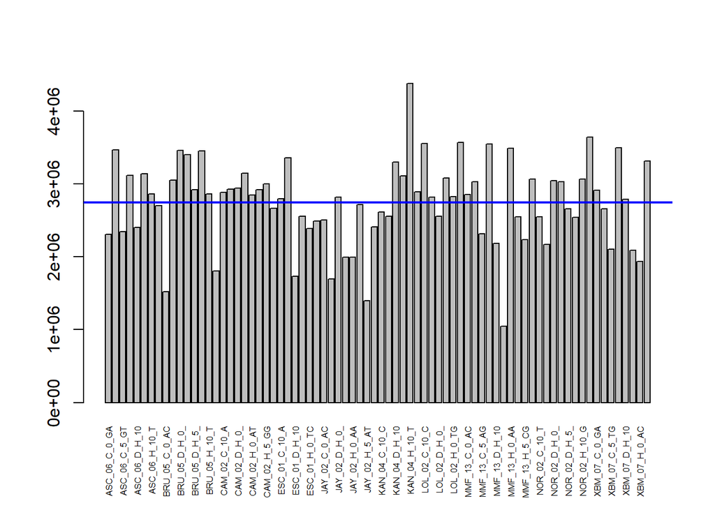

```r
barplot(colSums(countsTableRound),
        las=3,
        cex.names=0.5,
        names.arg = substring(colnames(countsTableRound),1,13))
abline(h=mean(colSums(countsTableRound)), col="blue", lwd =2)
```

```r
## What's the average no. of counts per gene
# rowSums(countsTableRound)  # commented out due to long output

mean(rowSums(countsTableRound))
```

```
## [1] 3139.743
```

```r
median(rowSums(countsTableRound)) # since expression data is not a normally distributed
```

```
## [1] 24
```

```r
# shows dispersion across genes - differenes in magnitude of epression

## What's the average no. of counts per gene per sample
apply(countsTableRound,2,mean)
```

```
##    ASC_06_C_0_GAGTCC_R1.cl.fq   ASC_06_C_10_ACGTCT_R1.cl.fq
##                      34.74738                      52.16539
##    ASC_06_C_5_GTGTAG_R1.cl.fq  ASC_06_D_H_0_CGCAAC_R1.cl.fq
##                      35.29608                      46.89962
## ASC_06_D_H_10_CAGCGT_R1.cl.fq    ASC_06_H_0_AATAGC_R1.cl.fq
##                      36.18382                      47.25641
##   ASC_06_H_10_TCGAGG_R1.cl.fq    ASC_06_H_5_CCGCAA_R1.cl.fq
##                      43.03183                      40.70017
##    BRU_05_C_0_ACCGTG_R1.cl.fq   BRU_05_C_10_GCATGG_R1.cl.fq
##                      22.89080                      45.99179
##  BRU_05_D_H_0_GCGAAT_R1.cl.fq BRU_05_D_H_10_GATTGT_R1.cl.fq
##                      52.07653                      51.17784
##  BRU_05_D_H_5_GGTATA_R1.cl.fq    BRU_05_H_0_TGGATT_R1.cl.fq
##                      43.93025                      52.00006
##   BRU_05_H_10_TTCCGC_R1.cl.fq    CAM_02_C_0_GGCTGC_R1.cl.fq
##                      43.03897                      27.14952
##   CAM_02_C_10_AACGCC_R1.cl.fq    CAM_02_C_5_TTAACT_R1.cl.fq
##                      43.38559                      44.02671
##  CAM_02_D_H_0_ATAAGA_R1.cl.fq CAM_02_D_H_10_AAGACA_R1.cl.fq
##                      44.30415                      47.40426
##    CAM_02_H_0_ATTGGT_R1.cl.fq   CAM_02_H_10_CAAGCA_R1.cl.fq
##                      42.90150                      43.96512
##    CAM_02_H_5_GGTGAG_R1.cl.fq    ESC_01_C_0_CAGATG_R1.cl.fq
##                      45.21646                      40.07492
##   ESC_01_C_10_ACAACG_R1.cl.fq  ESC_01_D_H_0_CGGTTA_R1.cl.fq
##                      42.12529                      50.53286
## ESC_01_D_H_10_TACCTT_R1.cl.fq  ESC_01_D_H_5_GACGAT_R1.cl.fq
##                      26.07678                      38.43483
##    ESC_01_H_0_TCAGGA_R1.cl.fq   ESC_01_H_10_ATGGCG_R1.cl.fq
##                      35.99587                      37.46147
##    JAY_02_C_0_ACCTAC_R1.cl.fq   JAY_02_C_10_TATGTC_R1.cl.fq
##                      37.68453                      25.51774
##  JAY_02_D_H_0_CCAATT_R1.cl.fq JAY_02_D_H_10_CGCCTG_R1.cl.fq
##                      42.45964                      30.08043
##    JAY_02_H_0_AACCGA_R1.cl.fq   JAY_02_H_10_CGATCT_R1.cl.fq
##                      29.98622                      40.84976
##    JAY_02_H_5_ATGAAC_R1.cl.fq    KAN_04_C_0_CACACT_R1.cl.fq
##                      21.00727                      36.28251
##   KAN_04_C_10_CGTCGC_R1.cl.fq  KAN_04_D_H_0_CAATGC_R1.cl.fq
##                      39.33638                      38.50376
```

[output cut: 21 more lines]

```
##                      38.36295                      32.71532
##  NOR_02_D_H_0_TCTTAA_R1.cl.fq NOR_02_D_H_10_GTGCCA_R1.cl.fq
##                      45.78334                      45.65052
##  NOR_02_D_H_5_CACTAA_R1.cl.fq    NOR_02_H_0_GTTACC_R1.cl.fq
##                      40.00256                      38.23874
##   NOR_02_H_10_GTAGAA_R1.cl.fq    NOR_02_H_5_GAAGTG_R1.cl.fq
##                      46.18416                      54.82794
##    XBM_07_C_0_GATCAC_R1.cl.fq   XBM_07_C_10_GCTCGA_R1.cl.fq
##                      43.81900                      40.05328
##    XBM_07_C_5_TGCACG_R1.cl.fq  XBM_07_D_H_0_ATATCC_R1.cl.fq
##                      31.64578                      52.60195
## XBM_07_D_H_10_GTCAGG_R1.cl.fq  XBM_07_D_H_5_CTAGTC_R1.cl.fq
##                      42.02280                      31.48926
##    XBM_07_H_0_ACCAGT_R1.cl.fq   XBM_07_H_10_GGAGGT_R1.cl.fq
##                      29.10853                      49.85314
```

```r
## Create a DESeq object and define the experimental design here with the tilde

dds <- DESeqDataSetFromMatrix(countData=countsTableRound,
                                      colData=conds,
                                      design= ~ climate + day + treatment)
#' replace pop with climate to check how much it differs on the [second run]

dim(dds)
```

```
## [1] 66408    76
```

```r
#'    [row]    [col]
#' [1] 66408    76

# Filter out genes with few reads
# the filtering level - at least one read per sample

dds <- dds[rowSums(counts(dds)) > 76]
dim(dds)
```

```
## [1] 23887    76
```

```r
#' [1] 23887    76
# this is filtering to sum of 76 read across all samples/one per each sample

# the filtering level - at least one read per 10 sample
#' dds <- dds[rowSums(counts(dds)) > 760]
#' dim(dds)
#' [1] 7884   76
# this is filtering to sum of 760 read across all samples/ten per each sample
```

## DEseq model

**Run the DESeq model to test for differential gene expression**  
1) Estimate size factors (per sample)  
2) Estimate dispersion (per gene)  
3) Run negative binomial glm

```r
dds <- DESeq(dds)
# List the results you've generated
resultsNames(dds)
```

```
## [1] "Intercept"        "climate_HD_vs_CW" "day_10_vs_0"      "day_5_vs_0"
## [5] "treatment_D_vs_C" "treatment_H_vs_C"
```

```r
#Running the model design: design= ~ pop + day + treatment
  #' [1] "Intercept"            "pop_BRU_05_vs_ASC_06"
  #' [3] "pop_CAM_02_vs_ASC_06" "pop_ESC_01_vs_ASC_06"
  #' [5] "pop_JAY_02_vs_ASC_06" "pop_KAN_04_vs_ASC_06"
  #' [7] "pop_LOL_02_vs_ASC_06" "pop_MMF_13_vs_ASC_06"
  #' [9] "pop_NOR_02_vs_ASC_06" "pop_XBM_07_vs_ASC_06"
  #' [11] "day_10_vs_0"          "day_5_vs_0"
  #' [13] "treatment_D_vs_C"     "treatment_H_vs_C"

#Running the model design: design= ~ climate + day + treatment
  #' [1] "Intercept"        "climate_HD_vs_CW" "day_10_vs_0"
  #' [4] "day_5_vs_0"       "treatment_D_vs_C" "treatment_H_vs_C"


# Order and list and summarize results from specific contrasts
# Here you set your adjusted p-value cutoff, can make summary tables of the number of genes differentially expressed (up- or down-regulated) for each contrast
res <- results(dds, alpha=0.05)
res <- res[order(res$padj),] #padj - adjusted p value


head(res)
```

```
## log2 fold change (MLE): treatment H vs C
## Wald test p-value: treatment H vs C
## DataFrame with 6 rows and 6 columns
##                          baseMean    log2FoldChange             lfcSE
##                         <numeric>         <numeric>         <numeric>
## MA_172878g0010   15.8548874481417  2.26899213338593 0.440654522862573
## MA_107783g0020    6.6082118492291 -1.96824414729965 0.394042285152139
## MA_28973g0010    18.8813749792546 -1.96646719472092 0.412333404130081
## MA_10434037g0010   5.611769238156  2.18536059760716 0.496716919353558
## MA_10426002g0010 10.8980752578363 -1.20767724886484  0.28313242027949
## MA_10429525g0010 60.5937645508928  1.17170086164903 0.281505776107562
##                               stat               pvalue                padj
##                          <numeric>            <numeric>           <numeric>
## MA_172878g0010    5.14914068882384  2.6168254972695e-07 0.00249278796869893
## MA_107783g0020   -4.99500744327406 5.88334982425963e-07 0.00280223952129486
## MA_28973g0010     -4.7691192976947 1.85033065465687e-06 0.00587541660542044
## MA_10434037g0010  4.39960974240871  1.0844572516574e-05   0.025826349448221
## MA_10426002g0010 -4.26541491671176 1.99531043148388e-05  0.0357522692443266
## MA_10429525g0010  4.16226223792056  3.1511017390706e-05  0.0357522692443266
```

```r
# log2 fold change (MLE): treatment H vs C
# Wald test p-value: treatment H vs C
# DataFrame with 6 rows and 6 columns
#                          baseMean    log2FoldChange             lfcSE              stat
#                         <numeric>         <numeric>         <numeric>         <numeric>
# MA_172878g0010   15.8548874481417  2.26899213338593 0.440654522862573  5.14914068882384
# MA_107783g0020    6.6082118492291 -1.96824414729965 0.394042285152139 -4.99500744327406
# MA_28973g0010    18.8813749792546 -1.96646719472092 0.412333404130081  -4.7691192976947
# MA_10434037g0010   5.611769238156  2.18536059760716 0.496716919353558  4.39960974240871
# MA_10426002g0010 10.8980752578363 -1.20767724886484  0.28313242027949 -4.26541491671176
# MA_10429525g0010 60.5937645508928  1.17170086164903 0.281505776107562  4.16226223792056
#                                pvalue                padj
#                             <numeric>           <numeric>
# MA_172878g0010    2.6168254972695e-07 0.00249278796869893
# MA_107783g0020   5.88334982425963e-07 0.00280223952129486
# MA_28973g0010    1.85033065465687e-06 0.00587541660542044
# MA_10434037g0010  1.0844572516574e-05   0.025826349448221
# MA_10426002g0010 1.99531043148388e-05  0.0357522692443266
# MA_10429525g0010  3.1511017390706e-05  0.0357522692443266

summary(res)
```

```
##
## out of 23887 with nonzero total read count
## adjusted p-value < 0.05
## LFC > 0 (up)       : 16, 0.067%
## LFC < 0 (down)     : 3, 0.013%
## outliers [1]       : 61, 0.26%
## low counts [2]     : 14300, 60%
## (mean count < 6)
## [1] see 'cooksCutoff' argument of ?results
## [2] see 'independentFiltering' argument of ?results
```

```r
#' out of 23887 with nonzero total read count
#' adjusted p-value < 0.05
#' LFC > 0 (up)       : 16, 0.067%
#' LFC < 0 (down)     : 3, 0.013%
#' outliers [1]       : 61, 0.26%
#' low counts [2]     : 14300, 60%
#' (mean count < 6)
#' [1] see 'cooksCutoff' argument of ?results
#' [2] see 'independentFiltering' argument of ?results



res_treatCD <- results(dds,
                       name="treatment_D_vs_C",
                       alpha=0.05)

head(res_treatCD)
```

```
## log2 fold change (MLE): treatment D vs C
## Wald test p-value: treatment D vs C
## DataFrame with 6 rows and 6 columns
##                          baseMean     log2FoldChange             lfcSE
##                         <numeric>          <numeric>         <numeric>
## MA_10001337g0010 10.5864076666598 -0.408466803124574 0.429134921643566
## MA_10002g0020    8.51169928861134  0.173584720553291 0.223875309840862
## MA_10003489g0010 13.4266539512183  0.676494552794233 0.411394288364556
## MA_100052g0010   1.05887192532892 -0.454722704581456 0.598142393724045
## MA_100058g0010   9.41059151389378  0.311937463362712 0.417562063937271
## MA_10006541g0010  3.2055053267771 -0.343027613082057 0.626094137214183
##                                stat            pvalue              padj
##                           <numeric>         <numeric>         <numeric>
## MA_10001337g0010   -0.9518377147219 0.341179291637839 0.681002159505927
## MA_10002g0020     0.775363396154227 0.438124958045008 0.756629581827304
## MA_10003489g0010   1.64439461588917 0.100094716547656 0.379074767523671
## MA_100052g0010   -0.760224838353865 0.447120200398816                NA
## MA_100058g0010    0.747044548111949 0.455036670759311 0.770181650225297
## MA_10006541g0010 -0.547885042668447 0.583770839764223 0.842834138475385
```

```r
res_treatCD <- res_treatCD[order(res_treatCD$padj),]
head(res_treatCD)
```

```
## log2 fold change (MLE): treatment D vs C
## Wald test p-value: treatment D vs C
## DataFrame with 6 rows and 6 columns
##                          baseMean   log2FoldChange             lfcSE
##                         <numeric>        <numeric>         <numeric>
## MA_10257300g0010 20.9979917001674 6.31608775716229 0.761778438070059
## MA_444738g0020   23.5872071084088 2.60491779951536 0.331247263623849
## MA_57964g0010    7.89927388331396 5.39652442842909 0.688793826922721
## MA_75192g0010    37.9183573851468 5.81210235837303 0.768762098604424
## MA_10428616g0010  35.758883777048 3.82582283371241   0.5106413925389
## MA_7017g0010     64.7924705055064 2.64439151272772 0.360360746750015
##                              stat               pvalue                 padj
##                         <numeric>            <numeric>            <numeric>
## MA_10257300g0010 8.29123986911982 1.12074011571862e-16 1.84462615646128e-12
## MA_444738g0020    7.8639677533258  3.7215338785869e-15 2.57743989395213e-11
## MA_57964g0010    7.83474563431962 4.69792799189281e-15 2.57743989395213e-11
## MA_75192g0010    7.56033936756775 4.02019076294696e-14  1.6542079941836e-10
## MA_10428616g0010 7.49219097709743 6.77332669685355e-14 2.22964368207025e-10
## MA_7017g0010     7.33817857959473 2.16520151830619e-13 5.93950863163359e-10
```

```r
# log2 fold change (MLE): treatment D vs C
# Wald test p-value: treatment D vs C
# DataFrame with 6 rows and 6 columns
#                          baseMean   log2FoldChange             lfcSE
#                         <numeric>        <numeric>         <numeric>
# MA_10257300g0010 20.9979917001674 6.31608775716229 0.761778438070059
# MA_444738g0020   23.5872071084088 2.60491779951536 0.331247263623849
# MA_57964g0010    7.89927388331396 5.39652442842909 0.688793826922721
# MA_75192g0010    37.9183573851468 5.81210235837303 0.768762098604424
# MA_10428616g0010  35.758883777048 3.82582283371241   0.5106413925389
# MA_7017g0010     64.7924705055064 2.64439151272772 0.360360746750015
#                              stat               pvalue                 padj
#                         <numeric>            <numeric>            <numeric>
# MA_10257300g0010 8.29123986911982 1.12074011571862e-16 1.84462615646128e-12
# MA_444738g0020    7.8639677533258  3.7215338785869e-15 2.57743989395213e-11
# MA_57964g0010    7.83474563431962 4.69792799189281e-15 2.57743989395213e-11
# MA_75192g0010    7.56033936756775 4.02019076294696e-14  1.6542079941836e-10
# MA_10428616g0010 7.49219097709743 6.77332669685355e-14 2.22964368207025e-10
# MA_7017g0010     7.33817857959473 2.16520151830619e-13 5.93950863163359e-10


summary(res_treatCD)
```

```
##
## out of 23887 with nonzero total read count
## adjusted p-value < 0.05
## LFC > 0 (up)       : 678, 2.8%
## LFC < 0 (down)     : 424, 1.8%
## outliers [1]       : 61, 0.26%
## low counts [2]     : 7367, 31%
## (mean count < 2)
## [1] see 'cooksCutoff' argument of ?results
## [2] see 'independentFiltering' argument of ?results
```

```r
# out of 23887 with nonzero total read count
# adjusted p-value < 0.05
# LFC > 0 (up)       : 678, 2.8%
# LFC < 0 (down)     : 424, 1.8%
# outliers [1]       : 61, 0.26%
# low counts [2]     : 7367, 31%
# (mean count < 2)
# [1] see 'cooksCutoff' argument of ?results
# [2] see 'independentFiltering' argument of ?results
```

## MA plot

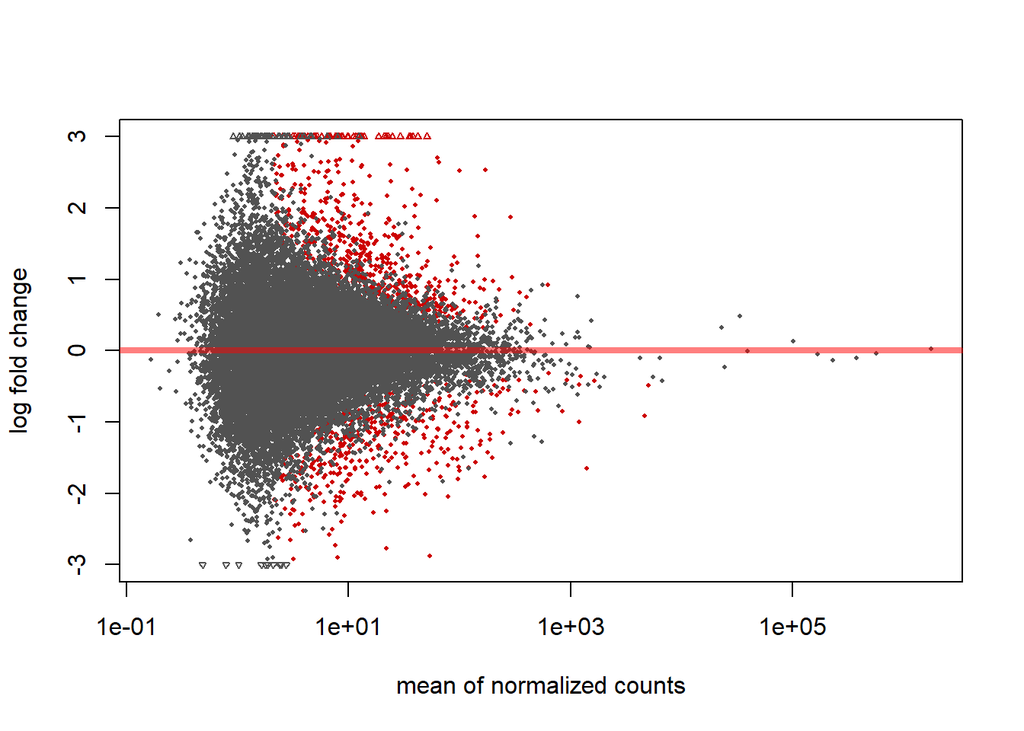

```r
##### Data visualization #####
# MA plot
plotMA(res_treatCD,ylim=c(-3,3))
```

```r
# differential expression on the y-axis as a function of means across the
# the samples; and the color indicates the significance levels
```

## PCA

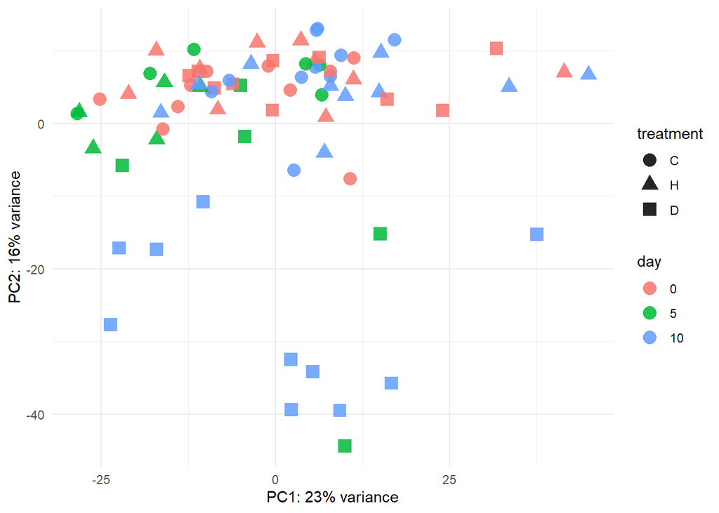

```r
# PCA
vsd <- vst(dds, blind=FALSE) #, nsub=10000

data <- plotPCA(vsd,intgroup=c("climate","treatment","day"), #ntop=10000
                returnData=TRUE)

# data <- plotPCA(vsd,intgroup=c("climate","treatment","day"),returnData=TRUE)
# percentVar <- round(100 * attr(data, "percentVar"))

percentVar <- round(100 * attr(data,"percentVar")) # to measure percent variance

data$treatment <- factor(data$treatment, levels=c("C","H","D"), labels = c("C","H","D"))
data$day <- factor(data$day, levels=c("0","5","10"), labels = c("0","5","10"))

# dev.off()
ggplot(data, aes(PC1, PC2, color=day, shape=treatment)) +
  geom_point(size=4, alpha=0.85) +
  xlab(paste0("PC1: ",percentVar[1],"% variance")) +
  ylab(paste0("PC2: ",percentVar[2],"% variance")) +
  theme_minimal()
```

```r
#' Counts of specific top gene! (important validatition that the normalization, model is working)
# MA_10257300g0010
d <-plotCounts(dds, gene="MA_10426407g0030", intgroup = (c("treatment","climate")), returnData=TRUE)
d
```

```
##                                   count treatment climate
## ASC_06_C_0_GAGTCC_R1.cl.fq     75.48857         C      HD
## ASC_06_C_10_ACGTCT_R1.cl.fq    63.29628         C      HD
## ASC_06_C_5_GTGTAG_R1.cl.fq     72.42212         C      HD
## ASC_06_D_H_0_CGCAAC_R1.cl.fq   69.73658         D      HD
## ASC_06_D_H_10_CAGCGT_R1.cl.fq 168.39437         D      HD
## ASC_06_H_0_AATAGC_R1.cl.fq     72.35867         H      HD
## ASC_06_H_10_TCGAGG_R1.cl.fq   108.27497         H      HD
## ASC_06_H_5_CCGCAA_R1.cl.fq    109.04625         H      HD
## BRU_05_C_0_ACCGTG_R1.cl.fq    192.94895         C      HD
## BRU_05_C_10_GCATGG_R1.cl.fq    32.81578         C      HD
## BRU_05_D_H_0_GCGAAT_R1.cl.fq   87.29646         D      HD
## BRU_05_D_H_10_GATTGT_R1.cl.fq 451.14458         D      HD
## BRU_05_D_H_5_GGTATA_R1.cl.fq   28.25267         D      HD
## BRU_05_H_0_TGGATT_R1.cl.fq     78.18519         H      HD
## BRU_05_H_10_TTCCGC_R1.cl.fq   142.29830         H      HD
## CAM_02_C_0_GGCTGC_R1.cl.fq    108.80869         C      CW
## CAM_02_C_10_AACGCC_R1.cl.fq    80.01281         C      CW
## CAM_02_C_5_TTAACT_R1.cl.fq     60.94549         C      CW
## CAM_02_D_H_0_ATAAGA_R1.cl.fq   84.92515         D      CW
## CAM_02_D_H_10_AAGACA_R1.cl.fq 412.69242         D      CW
## CAM_02_H_0_ATTGGT_R1.cl.fq    135.70494         H      CW
## CAM_02_H_10_CAAGCA_R1.cl.fq   121.01775         H      CW
## CAM_02_H_5_GGTGAG_R1.cl.fq    196.99334         H      CW
## ESC_01_C_0_CAGATG_R1.cl.fq     79.95344         C      HD
## ESC_01_C_10_ACAACG_R1.cl.fq    59.41476         C      HD
## ESC_01_D_H_0_CGGTTA_R1.cl.fq  107.08851         D      HD
## ESC_01_D_H_10_TACCTT_R1.cl.fq 564.83852         D      HD
## ESC_01_D_H_5_GACGAT_R1.cl.fq  149.39250         D      HD
## ESC_01_H_0_TCAGGA_R1.cl.fq     80.32968         H      HD
## ESC_01_H_10_ATGGCG_R1.cl.fq    85.95611         H      HD
## JAY_02_C_0_ACCTAC_R1.cl.fq     84.35144         C      CW
## JAY_02_C_10_TATGTC_R1.cl.fq    94.85018         C      CW
## JAY_02_D_H_0_CCAATT_R1.cl.fq   45.36390         D      CW
## JAY_02_D_H_10_CGCCTG_R1.cl.fq 258.71511         D      CW
## JAY_02_H_0_AACCGA_R1.cl.fq    117.74206         H      CW
## JAY_02_H_10_CGATCT_R1.cl.fq    72.32590         H      CW
## JAY_02_H_5_ATGAAC_R1.cl.fq    125.28551         H      CW
## KAN_04_C_0_CACACT_R1.cl.fq     88.48153         C      CW
## KAN_04_C_10_CGTCGC_R1.cl.fq    71.44613         C      CW
```

[output cut: 22 more lines]

```
## NOR_02_C_5_TCGTTC_R1.cl.fq     63.66654         C      HD
## NOR_02_D_H_0_TCTTAA_R1.cl.fq   49.52589         D      HD
## NOR_02_D_H_10_GTGCCA_R1.cl.fq 503.19329         D      HD
## NOR_02_D_H_5_CACTAA_R1.cl.fq  240.93813         D      HD
## NOR_02_H_0_GTTACC_R1.cl.fq     82.64705         H      HD
## NOR_02_H_10_GTAGAA_R1.cl.fq    97.69928         H      HD
## NOR_02_H_5_GAAGTG_R1.cl.fq    286.29189         H      HD
## XBM_07_C_0_GATCAC_R1.cl.fq     93.17233         C      HD
## XBM_07_C_10_GCTCGA_R1.cl.fq    71.01126         C      HD
## XBM_07_C_5_TGCACG_R1.cl.fq     56.41479         C      HD
## XBM_07_D_H_0_ATATCC_R1.cl.fq   79.75030         D      HD
## XBM_07_D_H_10_GTCAGG_R1.cl.fq 448.39977         D      HD
## XBM_07_D_H_5_CTAGTC_R1.cl.fq  242.05101         D      HD
## XBM_07_H_0_ACCAGT_R1.cl.fq    117.59591         H      HD
## XBM_07_H_10_GGAGGT_R1.cl.fq   158.73330         H      HD
```

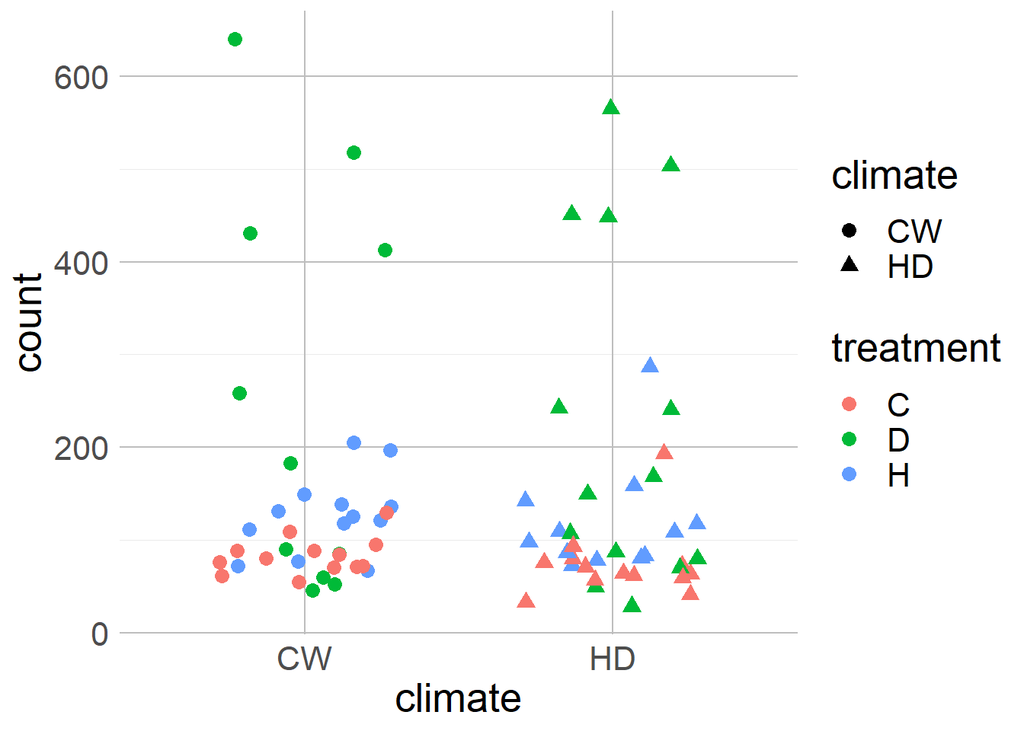

```r
p <-ggplot(d, aes(x=climate, y=count, shape=climate, colour = treatment)) +
  theme_minimal() + theme(text = element_text(size=20), panel.grid.major=element_line(colour="grey"))
p <- p + geom_point(position=position_jitter(w=0.3,h=0), size=3) +
  scale_x_discrete(limits=c("CW","HD"))
p
```

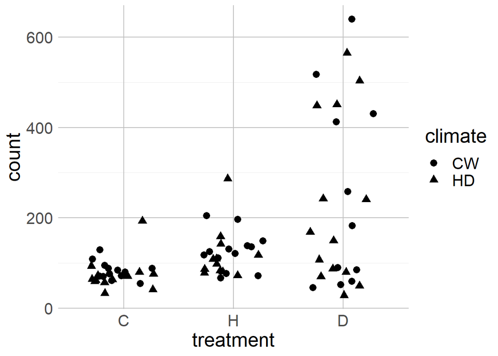

```r
# ------------------
p <-ggplot(d, aes(x=treatment, y=count, shape=climate)) +
  theme_minimal() + theme(text = element_text(size=20), panel.grid.major=element_line(colour="grey"))
p <- p + geom_point(position=position_jitter(w=0.3,h=0), size=3) +
  scale_x_discrete(limits=c("C","H","D"))
p
```

```r
# ----------------------------#

d <-plotCounts(dds, gene="MA_10257300g0010", intgroup = (c("treatment","climate","day")), returnData=TRUE)
d
```

```
##                                     count treatment climate day
## ASC_06_C_0_GAGTCC_R1.cl.fq      3.1781633         C      HD   0
## ASC_06_C_10_ACGTCT_R1.cl.fq     0.5000000         C      HD  10
## ASC_06_C_5_GTGTAG_R1.cl.fq      0.5000000         C      HD   5
## ASC_06_D_H_0_CGCAAC_R1.cl.fq   17.3238408         D      HD   0
## ASC_06_D_H_10_CAGCGT_R1.cl.fq   5.0376856         D      HD  10
## ASC_06_H_0_AATAGC_R1.cl.fq      1.2524468         H      HD   0
## ASC_06_H_10_TCGAGG_R1.cl.fq     0.9066980         H      HD  10
## ASC_06_H_5_CCGCAA_R1.cl.fq      0.5000000         H      HD   5
## BRU_05_C_0_ACCGTG_R1.cl.fq      0.5000000         C      HD   0
## BRU_05_C_10_GCATGG_R1.cl.fq     0.5000000         C      HD  10
## BRU_05_D_H_0_GCGAAT_R1.cl.fq    3.6562350         D      HD   0
## BRU_05_D_H_10_GATTGT_R1.cl.fq  67.9728839         D      HD  10
## BRU_05_D_H_5_GGTATA_R1.cl.fq    0.5000000         D      HD   5
## BRU_05_H_0_TGGATT_R1.cl.fq      1.8046368         H      HD   0
## BRU_05_H_10_TTCCGC_R1.cl.fq     9.5509552         H      HD  10
## CAM_02_C_0_GGCTGC_R1.cl.fq      2.9615611         C      CW   0
## CAM_02_C_10_AACGCC_R1.cl.fq     0.5000000         C      CW  10
## CAM_02_C_5_TTAACT_R1.cl.fq      2.9671630         C      CW   5
## CAM_02_D_H_0_ATAAGA_R1.cl.fq    0.5000000         D      CW   0
## CAM_02_D_H_10_AAGACA_R1.cl.fq 190.2929113         D      CW  10
## CAM_02_H_0_ATTGGT_R1.cl.fq      2.1289752         H      CW   0
## CAM_02_H_10_CAAGCA_R1.cl.fq     0.8074432         H      CW  10
## CAM_02_H_5_GGTGAG_R1.cl.fq      4.3679791         H      CW   5
## ESC_01_C_0_CAGATG_R1.cl.fq      0.5000000         C      HD   0
## ESC_01_C_10_ACAACG_R1.cl.fq     0.5000000         C      HD  10
## ESC_01_D_H_0_CGGTTA_R1.cl.fq    2.1335404         D      HD   0
## ESC_01_D_H_10_TACCTT_R1.cl.fq 174.0078064         D      HD  10
## ESC_01_D_H_5_GACGAT_R1.cl.fq   16.3243237         D      HD   5
## ESC_01_H_0_TCAGGA_R1.cl.fq      0.5000000         H      HD   0
## ESC_01_H_10_ATGGCG_R1.cl.fq     0.5000000         H      HD  10
## JAY_02_C_0_ACCTAC_R1.cl.fq      3.6727572         C      CW   0
## JAY_02_C_10_TATGTC_R1.cl.fq     0.5000000         C      CW  10
## JAY_02_D_H_0_CCAATT_R1.cl.fq    9.2539326         D      CW   0
## JAY_02_D_H_10_CGCCTG_R1.cl.fq  38.1563700         D      CW  10
## JAY_02_H_0_AACCGA_R1.cl.fq      2.8685264         H      CW   0
## JAY_02_H_10_CGATCT_R1.cl.fq     1.0746072         H      CW  10
## JAY_02_H_5_ATGAAC_R1.cl.fq      0.5000000         H      CW   5
## KAN_04_C_0_CACACT_R1.cl.fq      0.5000000         C      CW   0
## KAN_04_C_10_CGTCGC_R1.cl.fq     1.1449648         C      CW  10
```

[output cut: 22 more lines]

```
## NOR_02_C_5_TCGTTC_R1.cl.fq      0.5000000         C      HD   5
## NOR_02_D_H_0_TCTTAA_R1.cl.fq    2.5427455         D      HD   0
## NOR_02_D_H_10_GTGCCA_R1.cl.fq  51.4978699         D      HD  10
## NOR_02_D_H_5_CACTAA_R1.cl.fq  111.4714454         D      HD   5
## NOR_02_H_0_GTTACC_R1.cl.fq      0.5000000         H      HD   0
## NOR_02_H_10_GTAGAA_R1.cl.fq     0.5000000         H      HD  10
## NOR_02_H_5_GAAGTG_R1.cl.fq      0.5000000         H      HD   5
## XBM_07_C_0_GATCAC_R1.cl.fq      0.5000000         C      HD   0
## XBM_07_C_10_GCTCGA_R1.cl.fq     0.5000000         C      HD  10
## XBM_07_C_5_TGCACG_R1.cl.fq      3.1626089         C      HD   5
## XBM_07_D_H_0_ATATCC_R1.cl.fq    0.9354412         D      HD   0
## XBM_07_D_H_10_GTCAGG_R1.cl.fq  47.8133565         D      HD  10
## XBM_07_D_H_5_CTAGTC_R1.cl.fq   14.1085073         D      HD   5
## XBM_07_H_0_ACCAGT_R1.cl.fq      0.5000000         H      HD   0
## XBM_07_H_10_GGAGGT_R1.cl.fq     0.5000000         H      HD  10
```

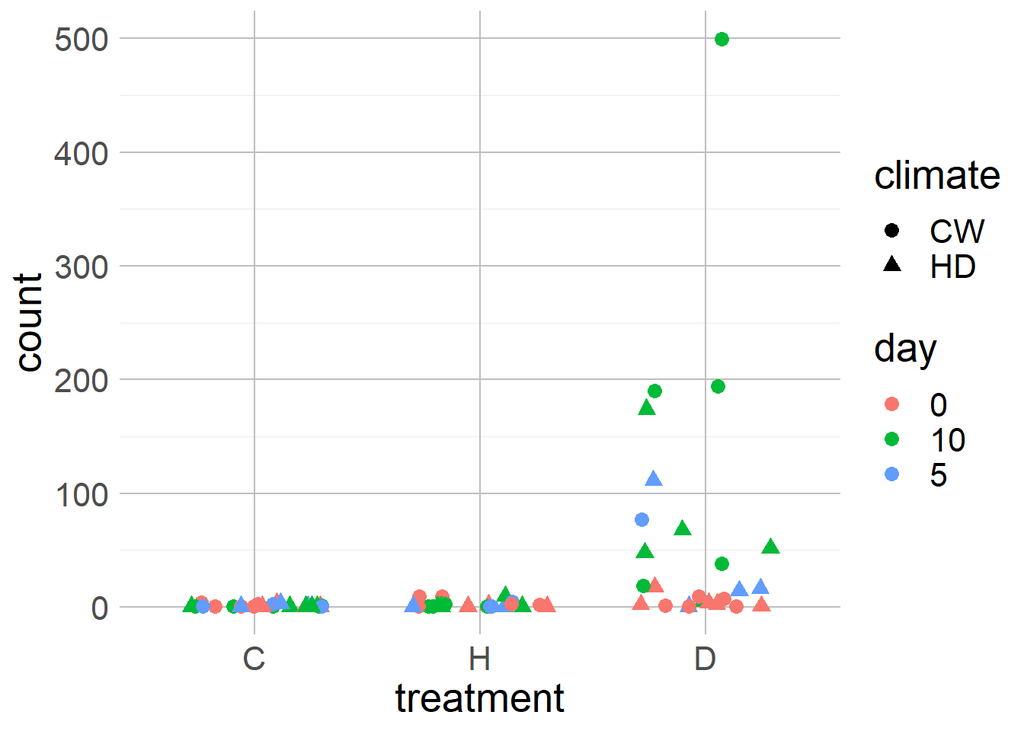

```r
p <-ggplot(d, aes(x=treatment, y=count, color=day, shape=climate)) +
  theme_minimal() + theme(text = element_text(size=20), panel.grid.major=element_line(colour="grey"))
p <- p + geom_point(position=position_jitter(w=0.3,h=0), size=3) +
  scale_x_discrete(limits=c("C","H","D"))
p
```

[figure not shown]

```r
# ----------------------------#
p <-ggplot(d, aes(x=treatment, y=count, shape=climate)) +
  theme_minimal() + theme(text = element_text(size=20), panel.grid.major=element_line(colour="grey"))
p
```

## Heatmap

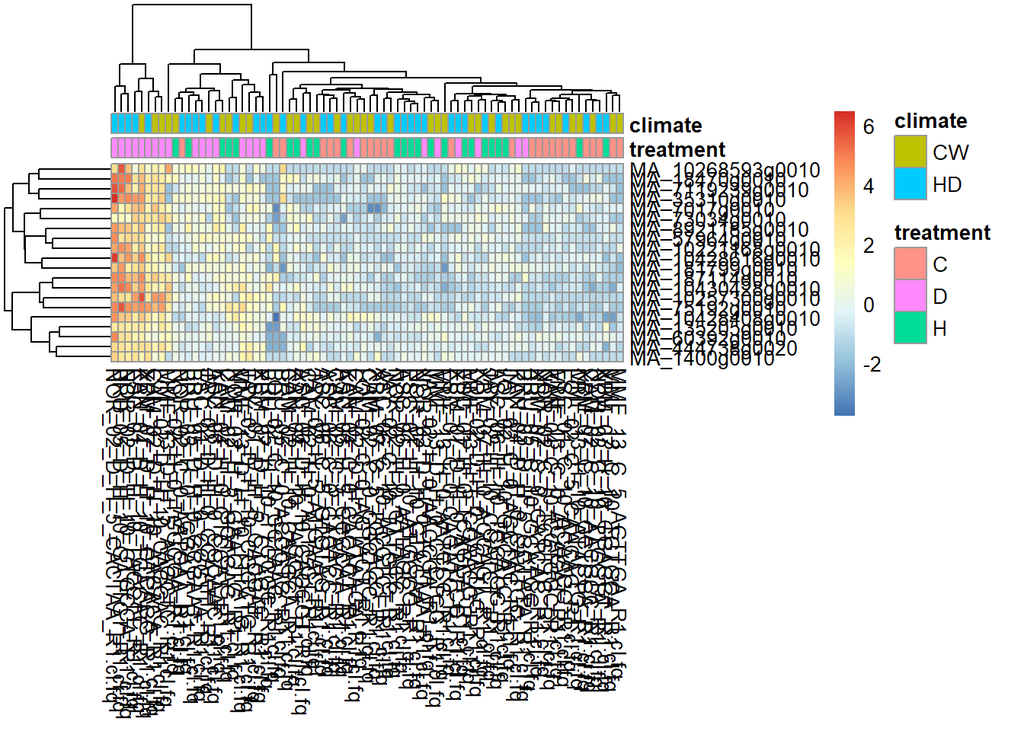

```r
# Heatmap of top 20 genes sorted by pvalue

topgenes <- head(rownames(res_treatCD),20)
mat <- assay(vsd)[topgenes,]
mat <- mat - rowMeans(mat)
df <- as.data.frame(colData(dds)[,c("treatment","climate")])
pheatmap(mat, annotation_col=df)
```

# Differential gene expression for for day 10 samples

### Program used : DESeq2

# Interaction model

## Set up experimental design

```r
## Import the counts matrix
countsTable <- read.table("./RS_counts_samples/RS_cds2kb_countsMatrix.txt",
                          header=TRUE,
                          row.names=1)
# head(countsTable) # commented out due to long output
dim(countsTable)
```

```
## [1] 66408    76
```

```r
countsTableRound <- round(countsTable) # Need to round because DESeq wants only integers
# head(countsTableRound) # commented out due to long output

## Import the samples description table - links each sample to factors of the experimental design.
# Need the colClasses otherwise imports "day" as numeric which DESeq doesn't like, coula altneratively change to d0, d5, d10
conds <- read.delim("./RS_counts_samples/RS_samples.txt",
                    header=TRUE,
                    stringsAsFactors = TRUE,
                    row.names=1,
                    colClasses=c('factor', 'factor', 'factor', 'factor'))
head(conds)
```

```
##                                  pop treatment day climate
## ASC_06_C_0_GAGTCC_R1.cl.fq    ASC_06         C   0      HD
## ASC_06_C_10_ACGTCT_R1.cl.fq   ASC_06         C  10      HD
## ASC_06_C_5_GTGTAG_R1.cl.fq    ASC_06         C   5      HD
## ASC_06_D_H_0_CGCAAC_R1.cl.fq  ASC_06         D   0      HD
## ASC_06_D_H_10_CAGCGT_R1.cl.fq ASC_06         D  10      HD
## ASC_06_H_0_AATAGC_R1.cl.fq    ASC_06         H   0      HD
```

```r
dim(conds)
```

```
## [1] 76  4
```

```r
######################## Only Day 10 data ######################################

# grep("10", names(countsTableRound), value = TRUE)
# day10countstable <- subset(countsTableRound, grep("10", names(countsTableRound), value = TRUE)) #doesn't work has to be logical

day10countstable <- countsTableRound %>% select(contains("10"))
dim(day10countstable)
```

```
## [1] 66408    30
```

```r
conds10 <- subset(conds, day=="10")
dim(conds10)
```

```
## [1] 30  4
```

```r
head(conds10)
```

```
##                                  pop treatment day climate
## ASC_06_C_10_ACGTCT_R1.cl.fq   ASC_06         C  10      HD
## ASC_06_D_H_10_CAGCGT_R1.cl.fq ASC_06         D  10      HD
## ASC_06_H_10_TCGAGG_R1.cl.fq   ASC_06         H  10      HD
## BRU_05_C_10_GCATGG_R1.cl.fq   BRU_05         C  10      HD
## BRU_05_D_H_10_GATTGT_R1.cl.fq BRU_05         D  10      HD
## BRU_05_H_10_TTCCGC_R1.cl.fq   BRU_05         H  10      HD
```

```r
dds <- DESeqDataSetFromMatrix(countData = day10countstable, colData = conds10,
                              design = ~ climate + treatment + climate:treatment)
dim(dds) # only 30 cols corresponding to the 30 samples for day 10
```

```
## [1] 66408    30
```

```r
nrow(dds) # another way to look at just the no. of samples (col no.)
```

```
## [1] 66408
```

```r
# Filter out genes with few reads
# the filtering level - at least one read per sample (here the total no. of samples are 30)

dds <- dds[rowSums(counts(dds)) > 30]
# row sums look at average no. of counts per gene (row names), and if it is less than 30,
# then that means that gene is not present in all the samples
dim(dds)
```

```
## [1] 24300    30
```

## DEseq model

**model: design = ~ climate + treatment + climate:treatment**  
- Interaction model

```r
dds <- DESeq(dds)
# List the results you've generated
resultsNames(dds)
```

```
## [1] "Intercept"            "climate_HD_vs_CW"     "treatment_D_vs_C"
## [4] "treatment_H_vs_C"     "climateHD.treatmentD" "climateHD.treatmentH"
```

```r
# Running the model: design = ~ climate + treatment + climate:treatment

# [1] "Intercept"            "climate_HD_vs_CW"     "treatment_D_vs_C"
# [4] "treatment_H_vs_C"     "climateHD.treatmentD" "climateHD.treatmentH"
```

**Significant genes for treatment effects**  
1. Treatment D vs C

```r
# Order and list and summarize results from specific contrasts
# Here you set your adjusted p-value cutoff, can make summary tables of the number of genes differentially expressed (up- or down-regulated) for each contrast
res_DC <- results(dds,
                  name="treatment_D_vs_C",
                  alpha = 0.05)
res_DC <- res_DC[order(res_DC$padj),]
head(res_DC)
```

```
## log2 fold change (MLE): treatment D vs C
## Wald test p-value: treatment D vs C
## DataFrame with 6 rows and 6 columns
##                          baseMean    log2FoldChange             lfcSE
##                         <numeric>         <numeric>         <numeric>
## MA_10426407g0030 219.715584286121  2.55696344469483 0.324906793273335
## MA_75192g0010    77.5190010889928  8.04619662596282  1.17408907419792
## MA_10425837g0010 293.426521892966 -3.17899129382686 0.462410078365211
## MA_824288g0010   154.710951677063 -4.15994435220765 0.610952834706398
## MA_133272g0010   9.82528137178526 -6.86599490523252  1.03504041639281
## MA_71201g0010    16.1438828561619 -7.29150111298197   1.1007571709411
##                               stat               pvalue                 padj
##                          <numeric>            <numeric>            <numeric>
## MA_10426407g0030  7.86983681976673 3.55104122313097e-15 4.77686065335578e-11
## MA_75192g0010     6.85313985351546 7.22463913264551e-12 3.23952818707825e-08
## MA_10425837g0010 -6.87483132951115 6.20632480288537e-12 3.23952818707825e-08
## MA_824288g0010   -6.80894516874902 9.83169393331512e-12 3.30639866977388e-08
## MA_133272g0010   -6.63355246470566 3.27702420845959e-11 7.83405828293912e-08
## MA_71201g0010    -6.62407777616205 3.49422760166776e-11 7.83405828293912e-08
```

```r
# log2 fold change (MLE): treatment D vs C
# Wald test p-value: treatment D vs C
# DataFrame with 6 rows and 6 columns
#                          baseMean    log2FoldChange             lfcSE
#                         <numeric>         <numeric>         <numeric>
# MA_10426407g0030 219.715584286121  2.55696344469483 0.324906793273335
# MA_75192g0010    77.5190010889928  8.04619662596282  1.17408907419792
# MA_10425837g0010 293.426521892966 -3.17899129382686 0.462410078365211
# MA_824288g0010   154.710951677063 -4.15994435220765 0.610952834706398
# MA_133272g0010   9.82528137178526 -6.86599490523252  1.03504041639281
# MA_71201g0010    16.1438828561619 -7.29150111298197   1.1007571709411
#                               stat               pvalue                 padj
#                          <numeric>            <numeric>            <numeric>
# MA_10426407g0030  7.86983681976673 3.55104122313097e-15 4.77686065335578e-11
# MA_75192g0010     6.85313985351546 7.22463913264551e-12 3.23952818707825e-08
# MA_10425837g0010 -6.87483132951115 6.20632480288537e-12 3.23952818707825e-08
# MA_824288g0010   -6.80894516874902 9.83169393331512e-12 3.30639866977388e-08
# MA_133272g0010   -6.63355246470566 3.27702420845959e-11 7.83405828293912e-08
# MA_71201g0010    -6.62407777616205 3.49422760166776e-11 7.83405828293912e-08

summary(res_DC)
```

```
##
## out of 24300 with nonzero total read count
## adjusted p-value < 0.05
## LFC > 0 (up)       : 257, 1.1%
## LFC < 0 (down)     : 327, 1.3%
## outliers [1]       : 118, 0.49%
## low counts [2]     : 10730, 44%
## (mean count < 3)
## [1] see 'cooksCutoff' argument of ?results
## [2] see 'independentFiltering' argument of ?results
```

```r
# out of 24300 with nonzero total read count
# adjusted p-value < 0.05
# LFC > 0 (up)       : 257, 1.1%
# LFC < 0 (down)     : 327, 1.3%
# outliers [1]       : 118, 0.49%
# low counts [2]     : 10730, 44%
# (mean count < 3)
# [1] see 'cooksCutoff' argument of ?results
# [2] see 'independentFiltering' argument of ?results

# 257 genes upregulated and 327 genes down regulated
```

2. Treatment H vs C

```r
res_HC <- results(dds,
                  name="treatment_H_vs_C",
                  alpha = 0.05)
res_HC <- res_HC[order(res_HC$padj),]
head(res_HC)
```

```
## log2 fold change (MLE): treatment H vs C
## Wald test p-value: treatment H vs C
## DataFrame with 6 rows and 6 columns
##                          baseMean    log2FoldChange             lfcSE
##                         <numeric>         <numeric>         <numeric>
## MA_10433227g0010 125.510230112695  3.26707905818489 0.641361831156057
## MA_10435662g0010 8.28699601140931 -7.05408028075111  1.50340372681173
## MA_5409604g0010  7.29512610271943 -4.88577315799737  1.04447376975162
## MA_10243352g0010 26.4607070894793  4.20442889158221  0.97215011030973
## MA_10427910g0010  22.037007847001  4.44212975412583  1.03334482980114
## MA_2145g0010     95.3899101513183  2.78020586763242 0.637078978276453
##                               stat               pvalue               padj
##                          <numeric>            <numeric>          <numeric>
## MA_10433227g0010  5.09397176363921 3.50639011713097e-07 0.0084791525812461
## MA_10435662g0010 -4.69207316368087 2.70450368168049e-06 0.0233806756768932
## MA_5409604g0010  -4.67773657844871 2.90058833143162e-06 0.0233806756768932
## MA_10243352g0010  4.32487621715402 1.52617534938053e-05 0.0692149659971974
## MA_10427910g0010  4.29878741927868 1.71735090556275e-05 0.0692149659971974
## MA_2145g0010      4.36398933638333 1.27711805204037e-05 0.0692149659971974
```

```r
# log2 fold change (MLE): treatment H vs C
# Wald test p-value: treatment H vs C
# DataFrame with 6 rows and 6 columns
#                          baseMean    log2FoldChange             lfcSE              stat
#                         <numeric>         <numeric>         <numeric>         <numeric>
# MA_10433227g0010 125.510230112695  3.26707905818489 0.641361831156057  5.09397176363921
# MA_10435662g0010 8.28699601140931 -7.05408028075111  1.50340372681173 -4.69207316368087
# MA_5409604g0010  7.29512610271943 -4.88577315799737  1.04447376975162 -4.67773657844871
# MA_10243352g0010 26.4607070894793  4.20442889158221  0.97215011030973  4.32487621715402
# MA_10427910g0010  22.037007847001  4.44212975412583  1.03334482980114  4.29878741927868
# MA_2145g0010     95.3899101513183  2.78020586763242 0.637078978276453  4.36398933638333
#                                pvalue               padj
#                             <numeric>          <numeric>
# MA_10433227g0010 3.50639011713097e-07 0.0084791525812461
# MA_10435662g0010 2.70450368168049e-06 0.0233806756768932
# MA_5409604g0010  2.90058833143162e-06 0.0233806756768932
# MA_10243352g0010 1.52617534938053e-05 0.0692149659971974
# MA_10427910g0010 1.71735090556275e-05 0.0692149659971974
# MA_2145g0010     1.27711805204037e-05 0.0692149659971974

summary(res_HC)
```

```
##
## out of 24300 with nonzero total read count
## adjusted p-value < 0.05
## LFC > 0 (up)       : 1, 0.0041%
## LFC < 0 (down)     : 2, 0.0082%
## outliers [1]       : 118, 0.49%
## low counts [2]     : 0, 0%
## (mean count < 0)
## [1] see 'cooksCutoff' argument of ?results
## [2] see 'independentFiltering' argument of ?results
```

```r
# out of 24300 with nonzero total read count
# adjusted p-value < 0.05
# LFC > 0 (up)       : 1, 0.0041%
# LFC < 0 (down)     : 2, 0.0082%
# outliers [1]       : 118, 0.49%
# low counts [2]     : 0, 0%
# (mean count < 0)
# [1] see 'cooksCutoff' argument of ?results
# [2] see 'independentFiltering' argument of ?results

# one gene up regulated and two genes down regualted
```

**Genes significant for the interaction effects** No genes were up or down regulated for the interaction effects

```r
########################interactions#####################################
res_interClimTreat <- results(dds,
                              name="climateHD.treatmentD",
                              alpha=0.05)
res_interClimTreat <- res_interClimTreat[order(res_interClimTreat$padj),]
head(res_interClimTreat)
```

```
## log2 fold change (MLE): climateHD.treatmentD
## Wald test p-value: climateHD.treatmentD
## DataFrame with 6 rows and 6 columns
##                          baseMean    log2FoldChange            lfcSE
##                         <numeric>         <numeric>        <numeric>
## MA_10099827g0020 4.83853396229387  9.19407788907397 2.67416354281987
## MA_10425937g0010 25.6559126238508 -21.2964262248859 5.99890084637978
## MA_10430081g0010 2.90596431040824  5.21480283767419 1.54366557132569
## MA_10435232g0010 10.7835206016659  3.60553079977203 1.07187465780707
## MA_125231g0010   3.42589829850778  6.76981963555466 2.01388774540484
## MA_140915g0010   11.7959781847135  4.11326647618263 1.15416231213143
##                               stat               pvalue              padj
##                          <numeric>            <numeric>         <numeric>
## MA_10099827g0020  3.43811354161942 0.000585782021894424 0.856302113236214
## MA_10425937g0010 -3.55005471339601 0.000385151095351281 0.856302113236214
## MA_10430081g0010   3.3781946909626 0.000729634032140524 0.856302113236214
## MA_10435232g0010  3.36376158677782 0.000768879326181142 0.856302113236214
## MA_125231g0010    3.36156752083209 0.000775014055533342 0.856302113236214
## MA_140915g0010    3.56385443619844 0.000365448665721064 0.856302113236214
```

```r
summary(res_interClimTreat)
```

```
##
## out of 24300 with nonzero total read count
## adjusted p-value < 0.05
## LFC > 0 (up)       : 0, 0%
## LFC < 0 (down)     : 0, 0%
## outliers [1]       : 118, 0.49%
## low counts [2]     : 0, 0%
## (mean count < 0)
## [1] see 'cooksCutoff' argument of ?results
## [2] see 'independentFiltering' argument of ?results
```

```r
res_interClimTreat1 <- results(dds,
                              name="climateHD.treatmentH",
                              alpha=0.05)
res_interClimTreat1 <- res_interClimTreat1[order(res_interClimTreat1$padj),]
head(res_interClimTreat1)
```

```
## log2 fold change (MLE): climateHD.treatmentH
## Wald test p-value: climateHD.treatmentH
## DataFrame with 6 rows and 6 columns
##                          baseMean    log2FoldChange            lfcSE
##                         <numeric>         <numeric>        <numeric>
## MA_468819g0010   40.8964308972913 -5.49893442992202  1.2153990026412
## MA_84252g0010    104.084115269423  5.60660863214681 1.32058006386761
## MA_10436776g0040 8.63570655365942 -7.47480230271197 1.87332459051505
## MA_138049g0010   417.386947466876  6.88960741107083 1.79709679286005
## MA_165691g0010   10.5802831728247  6.19303106180771 1.64121032138824
## MA_51861g0010    6.12721004865036  -4.0695313173161  1.1161856590673
##                               stat               pvalue              padj
##                          <numeric>            <numeric>         <numeric>
## MA_468819g0010   -4.52438616287508 6.05710436438864e-06 0.146472897739646
## MA_84252g0010     4.24556510093498 2.18043188151868e-05 0.263636018794424
## MA_10436776g0040 -3.99012661263197 6.60380336915172e-05 0.532310576909423
## MA_138049g0010    3.83374308965636 0.000126207956704206 0.762990202255277
## MA_165691g0010    3.77345364034102 0.000161003148488145 0.778675627348064
## MA_51861g0010    -3.64592689778568 0.000266429713743287 0.934929433856669
```

```r
summary(res_interClimTreat1)
```

```
##
## out of 24300 with nonzero total read count
## adjusted p-value < 0.05
## LFC > 0 (up)       : 0, 0%
## LFC < 0 (down)     : 0, 0%
## outliers [1]       : 118, 0.49%
## low counts [2]     : 0, 0%
## (mean count < 0)
## [1] see 'cooksCutoff' argument of ?results
## [2] see 'independentFiltering' argument of ?results
```

**Significant genes for climate od origin**

```r
res_clim <- results(dds,
                  name="climate_HD_vs_CW",
                  alpha = 0.05)
res_clim <- res_clim[order(res_clim$padj),]
head(res_clim)
```

```
## log2 fold change (MLE): climate HD vs CW
## Wald test p-value: climate HD vs CW
## DataFrame with 6 rows and 6 columns
##                          baseMean    log2FoldChange             lfcSE
##                         <numeric>         <numeric>         <numeric>
## MA_129323g0010   324.262262704518 -21.5499067186968  4.32625922212836
## MA_16728g0010    8.40223848058947 -3.36470592814229 0.823066161783521
## MA_10431838g0020 10.0290447486102 -5.53429086970662  1.39604511851967
## MA_10436083g0020 4.93143039857709   4.2414434876428  1.11124473551835
## MA_15203g0010    5.64627297365219 -5.78813293657449  1.53995776640546
## MA_10436434g0010 4.64254778093651  5.05679638671374  1.33754612155652
##                               stat               pvalue              padj
##                          <numeric>            <numeric>         <numeric>
## MA_129323g0010   -4.98118712084364  6.3195395264759e-07 0.015281910482924
## MA_16728g0010    -4.08801392205365 4.35082048593866e-05 0.526057704954844
## MA_10431838g0020 -3.96426361604633 7.36228593082993e-05 0.590198362832058
## MA_10436083g0020  3.81684011818004 0.000135171698207869 0.590198362832058
## MA_15203g0010    -3.75863095913666 0.000170845609950559 0.590198362832058
## MA_10436434g0010   3.7806519754467 0.000156418202273893 0.590198362832058
```

```r
summary(res_clim)
```

```
##
## out of 24300 with nonzero total read count
## adjusted p-value < 0.05
## LFC > 0 (up)       : 0, 0%
## LFC < 0 (down)     : 1, 0.0041%
## outliers [1]       : 118, 0.49%
## low counts [2]     : 0, 0%
## (mean count < 0)
## [1] see 'cooksCutoff' argument of ?results
## [2] see 'independentFiltering' argument of ?results
```

## MA plot

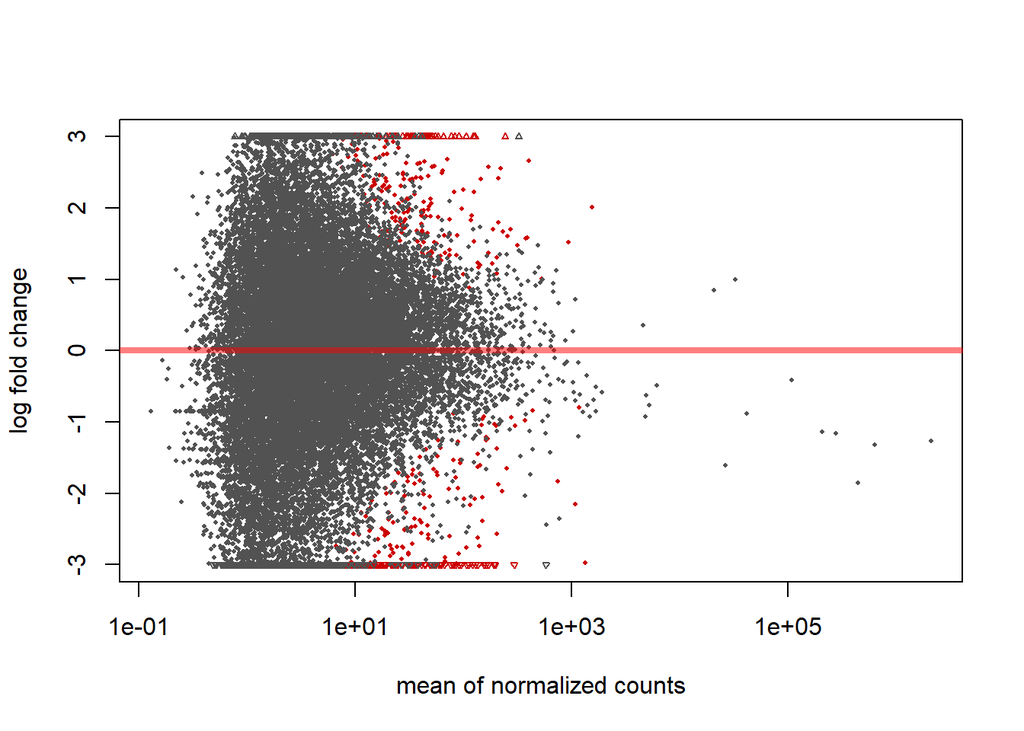

```r
# MA plot

# for drought treatment
plotMA(res_DC,ylim=c(-3,3))
```

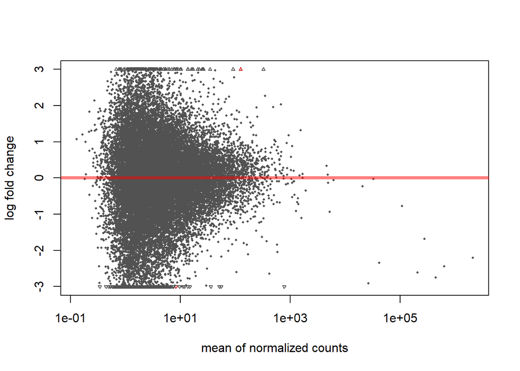

```r
# for hot treatment
plotMA(res_HC,ylim=c(-3,3))
```

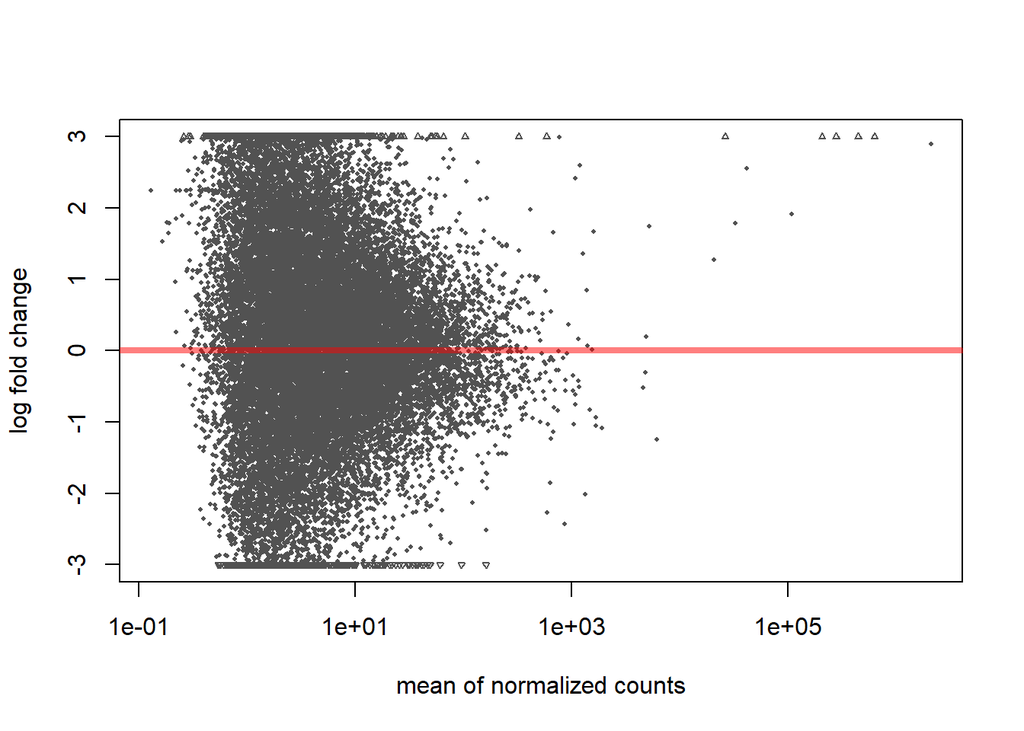

```r
# interaction
plotMA(res_interClimTreat,ylim=c(-3,3))
```

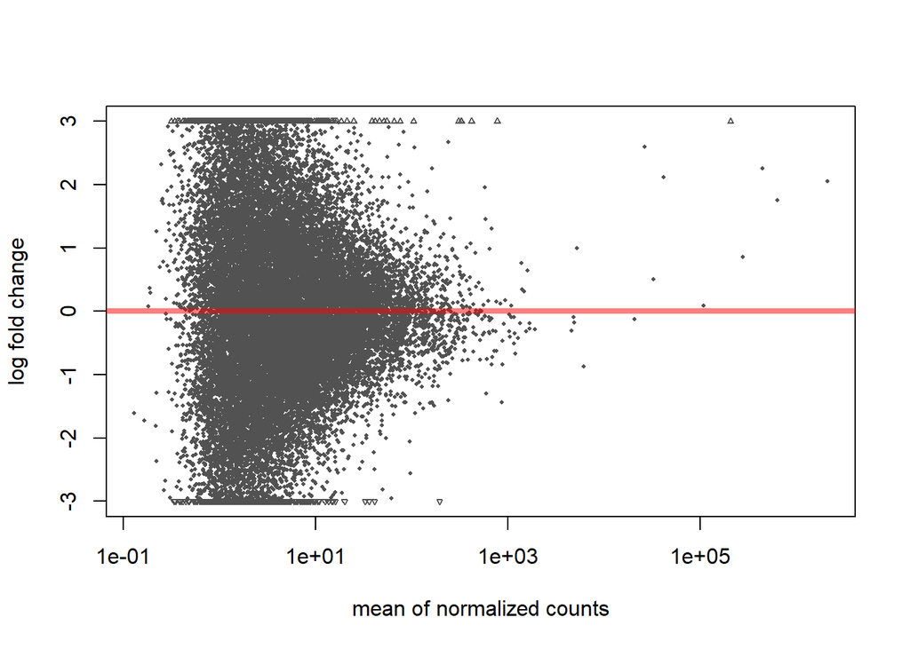

```r
# no significant expression levels observed for the interaction of HotDry climate
# and the Drought treatment

plotMA(res_interClimTreat1,ylim=c(-3,3))
```

## PCA plot

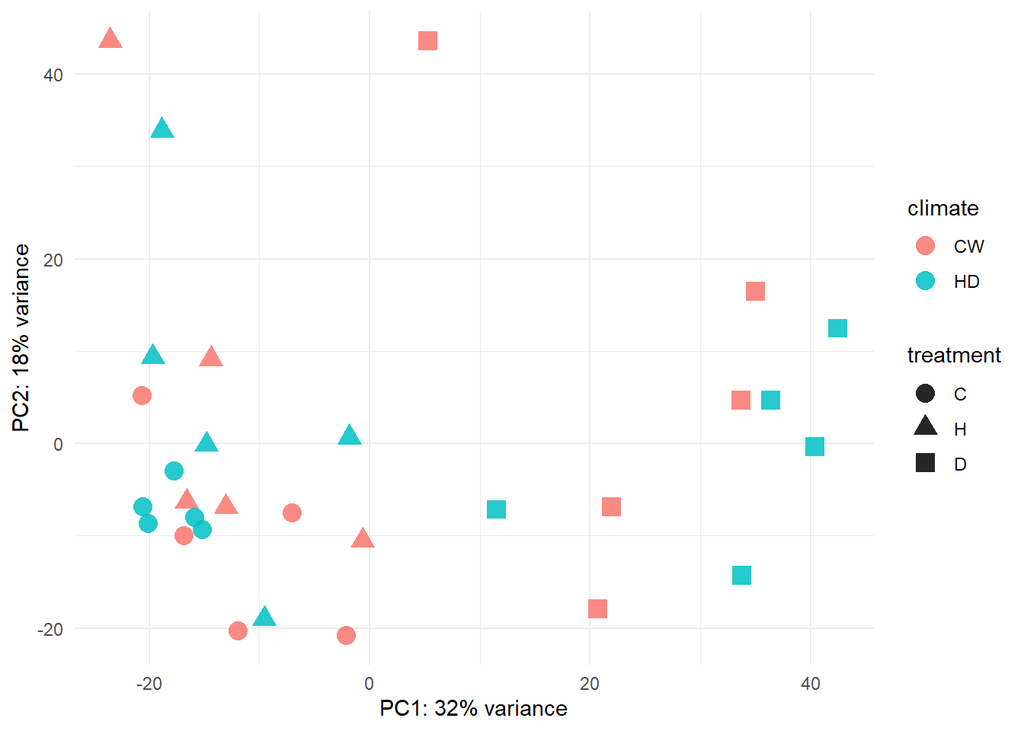

```r
# PCA
vsd <- vst(dds, blind=FALSE) #, nsub=10000

data <- plotPCA(vsd,intgroup=c("climate","treatment","pop"), #ntop=10000
                returnData=TRUE)



percentVar <- round(100 * attr(data,"percentVar")) # to measure percent variance

data$treatment <- factor(data$treatment, levels=c("C","H","D"), labels = c("C","H","D"))

ggplot(data, aes(PC1, PC2, color=climate, shape=treatment)) +
  geom_point(size=4, alpha=0.85) +
  xlab(paste0("PC1: ",percentVar[1],"% variance")) +
  ylab(paste0("PC2: ",percentVar[2],"% variance")) +
  theme_minimal()
```

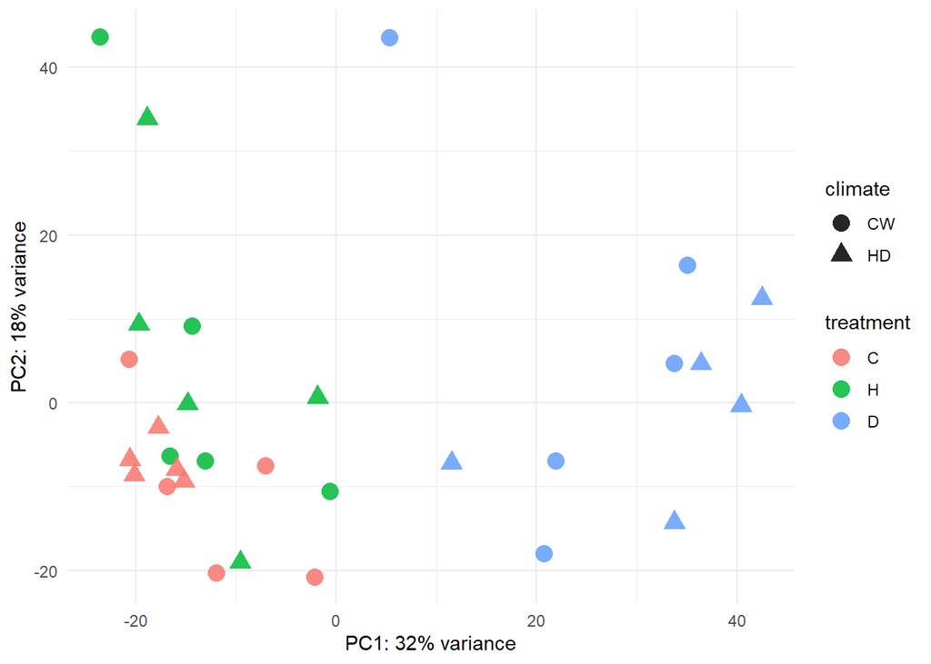

```r
ggplot(data, aes(PC1, PC2, color=treatment, shape=climate)) +
  geom_point(size=4, alpha=0.85) +
  xlab(paste0("PC1: ",percentVar[1],"% variance")) +
  ylab(paste0("PC2: ",percentVar[2],"% variance")) +
  theme_minimal()
```

## Heatmap

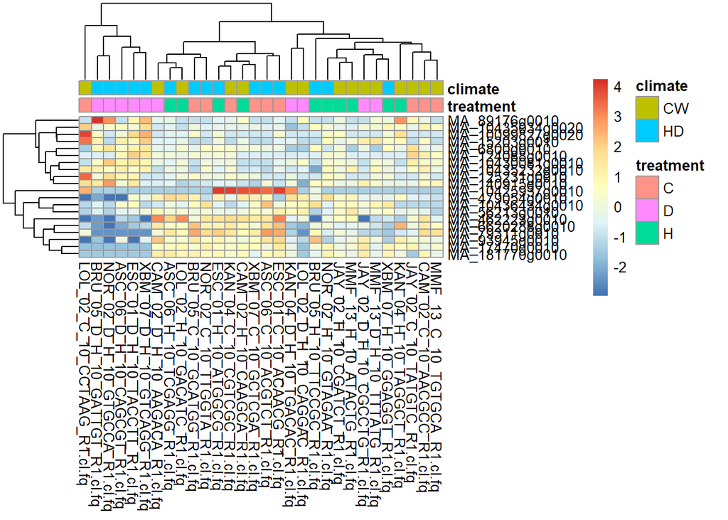

```r
# Heatmap of top 20 genes sorted by pvalue for interaction

topgenes <- head(rownames(res_interClimTreat),20)
mat <- assay(vsd)[topgenes,]
mat <- mat - rowMeans(mat)
df <- as.data.frame(colData(dds)[,c("treatment","climate")])
pheatmap(mat, annotation_col=df)
```

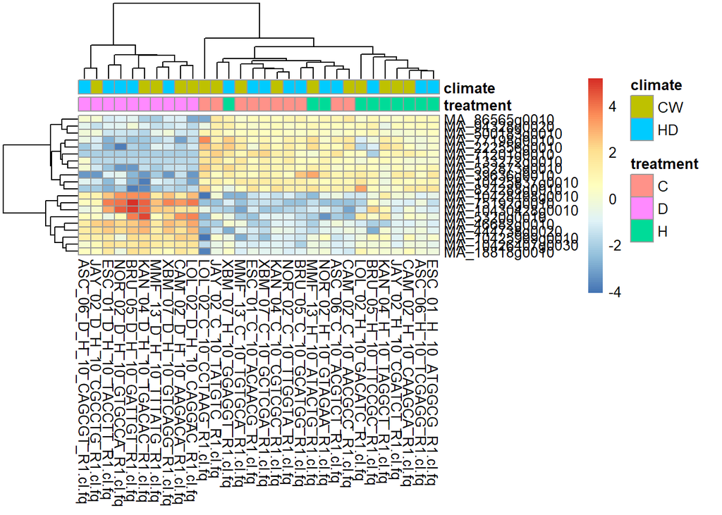

```r
# Heatmap of top 20 genes sorted by pvalue for drought treatment

topgenes <- head(rownames(res_DC),20)
mat <- assay(vsd)[topgenes,]
mat <- mat - rowMeans(mat)
df <- as.data.frame(colData(dds)[,c("treatment","climate")])
pheatmap(mat, annotation_col=df)
```

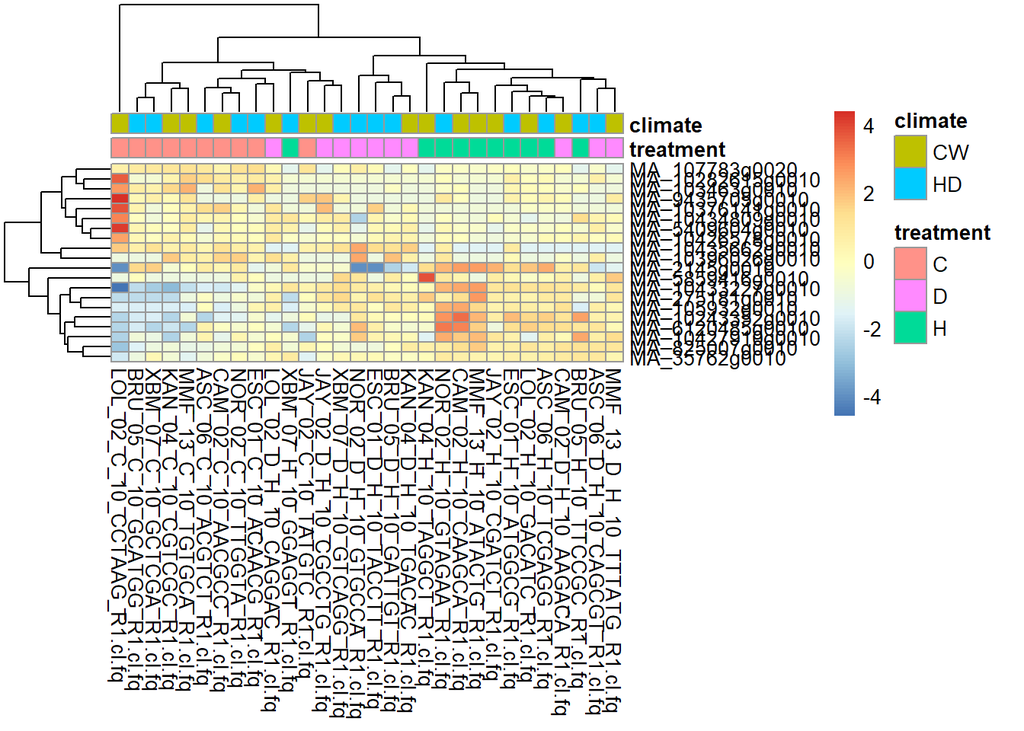

```r
# Heatmap of top 20 genes sorted by pvalue for hot treatment

topgenes <- head(rownames(res_HC),20)
mat <- assay(vsd)[topgenes,]
mat <- mat - rowMeans(mat)
df <- as.data.frame(colData(dds)[,c("treatment","climate")])
pheatmap(mat, annotation_col=df)
```

## Significant genes

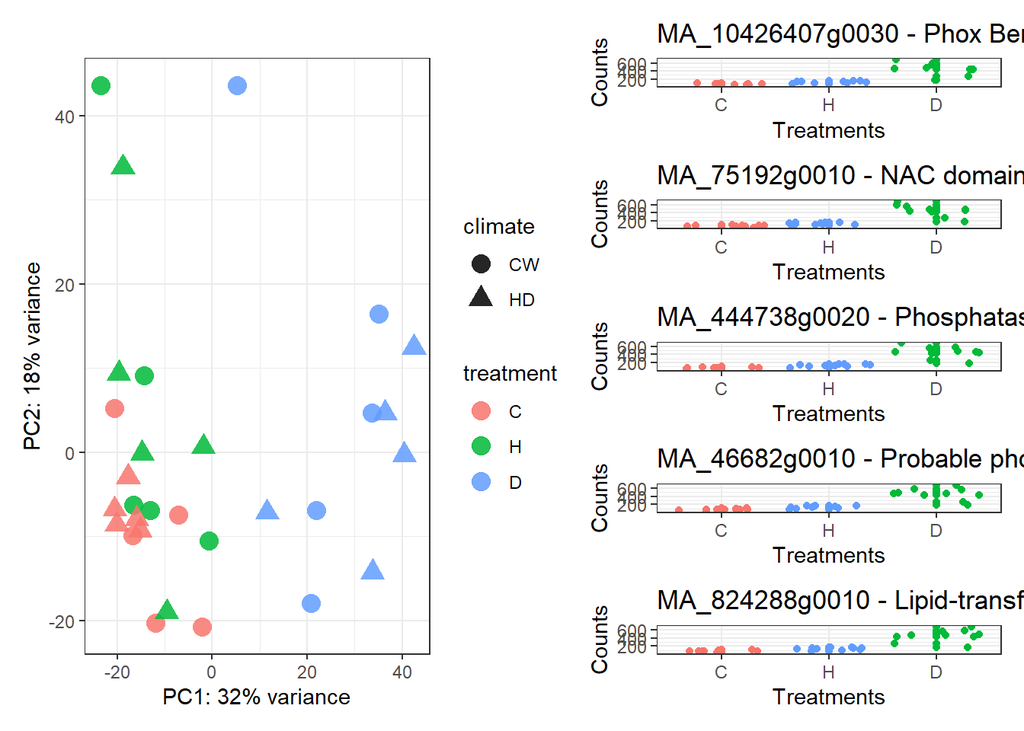

```r
# for Drought vs Control contrast
topgenes5 <- head(rownames(res_DC),5)


# "MA_10426407g0030"
# PB1 domain
gene1 <-plotCounts(dds,
                   gene="MA_10426407g0030",
                   intgroup = ("treatment"),
                   returnData=TRUE)

gene1_plot <- ggplot(gene1,
                     aes(x=treatment,y=count, col=treatment)) +
              geom_point() +
              geom_jitter() +
              theme_bw() +
              scale_x_discrete(limits = c("C", "H", "D")) +
              theme(legend.position="none") +
              xlab("Treatments") + ylab("Counts") +
              ggtitle("MA_10426407g0030 - Phox Bem1p")



# "MA_75192g0010"
# biological process - regulation of cellular process, reponse to stimulus
# No apical meristem (NAM) protein
gene2 <-plotCounts(dds,
                   gene="MA_75192g0010",
                   intgroup = ("treatment"),
                   returnData=TRUE)

gene2_plot <- ggplot(gene1,
                     aes(x=treatment,y=count, col=treatment)) +
              geom_point() +
              geom_jitter() +
              theme_bw() +
              scale_x_discrete(limits = c("C", "H", "D")) +
              theme(legend.position="none") +
              xlab("Treatments") + ylab("Counts") +
              ggtitle("MA_75192g0010 - NAC domain-containing 68-like")

# "MA_444738g0020"
# molecular function - catalytic activity
# Protein phosphatase 2C, Stage II sporulation protein E (SpoIIE)
gene3 <-plotCounts(dds,
                   gene="MA_444738g0020",
                   intgroup = ("treatment"),
                   returnData=TRUE)

gene3_plot <- ggplot(gene1,
                     aes(x=treatment,y=count, col=treatment)) +
              geom_point() +
              geom_jitter() +
              theme_bw() +
              scale_x_discrete(limits = c("C", "H", "D")) +
              theme(legend.position="none") +
              xlab("Treatments") + ylab("Counts") +
              ggtitle("MA_444738g0020 - Phosphatase 2C")

# "MA_46682g0010"
# Protein phosphatase 2C
gene4 <-plotCounts(dds,
                   gene="MA_46682g0010",
                   intgroup = ("treatment"),
                   returnData=TRUE)

gene4_plot <- ggplot(gene1,
                     aes(x=treatment,y=count, col=treatment)) +
              geom_point() +
              geom_jitter() +
              theme_bw() +
              scale_x_discrete(limits = c("C", "H", "D")) +
              theme(legend.position="none") +
              xlab("Treatments") + ylab("Counts") +
              ggtitle("MA_46682g0010 - Probable phosphatase 2C 8")

# "MA_824288g0010"
# Protease inhibitor/seed storage/LTP family, Probable lipid transfer
gene5 <-plotCounts(dds,
                   gene="MA_824288g0010",
                   intgroup = ("treatment"),
                   returnData=TRUE)

gene5_plot <- ggplot(gene1,
                     aes(x=treatment,y=count, col=treatment)) +
              geom_point() +
              geom_jitter() +
              theme_bw() +
              scale_x_discrete(limits = c("C", "H", "D")) +
              theme(legend.position="none") +
              xlab("Treatments") + ylab("Counts") +
              ggtitle("MA_824288g0010 - Lipid-transfer DIR1")


PCA <- ggplot(data, aes(PC1, PC2, color=treatment, shape=climate)) +
        geom_point(size=4, alpha=0.85) +
        xlab(paste0("PC1: ",percentVar[1],"% variance")) +
        ylab(paste0("PC2: ",percentVar[2],"% variance")) +
        theme_bw()



PCA + (gene1_plot / gene2_plot / gene3_plot/  gene4_plot/ gene5_plot)
```

```r
# for Heat vs Control contrast
topgenes5 <- head(rownames(res_HC),5)

# "MA_10433227g0010"
# biological stress - response to stress
# KDa class I heat shock -like


# "MA_10243352g0010"
# KDa class IV heat shock -like
# biolocal process - protein folding
# cellular component - endoplasmic reticulum
# Hsp20/alpha crystallin family, CS domain


# "MA_10429149g0010"
# novel gene



# "MA_10429775g0010"
# BAG family molecular chaperone regulator 6


# "MA_8624541g0010"
# novel gene
# PspA/IM30 family, Viral A-type inclusion protein repeat,
# Septum formation initiator, Protein of unknown function (DUF904),
# Laminin Domain II
```

# Treatment model

## Experimental design

```r
dds <- DESeqDataSetFromMatrix(countData = day10countstable, colData = conds10,
                              design = ~ climate + treatment)
dim(dds)
```

```
## [1] 66408    30
```

```r
nrow(dds)
```

```
## [1] 66408
```

```r
# Filter out genes with few reads
# the filtering level - at least one read per sample (here the total no. of samples are 30)

dds <- dds[rowSums(counts(dds)) > 30]

dim(dds)
```

```
## [1] 24300    30
```

## DEseq model

**model: design = ~ climate + treatment**

```r
dds <- DESeq(dds)
# List the results generated
resultsNames(dds)
```

```
## [1] "Intercept"        "climate_HD_vs_CW" "treatment_D_vs_C" "treatment_H_vs_C"
```

**Significant genes for treatment effects**  
1. Treatment D vs C

```r
# Order and list and summarize results from specific contrasts
# Here you set your adjusted p-value cutoff, can make summary tables of the number of genes differentially expressed (up- or down-regulated) for each contrast
res_DC <- results(dds,
                  name="treatment_D_vs_C",
                  alpha = 0.05)
res_DC <- res_DC[order(res_DC$padj),]
head(res_DC)
```

```
## log2 fold change (MLE): treatment D vs C
## Wald test p-value: treatment D vs C
## DataFrame with 6 rows and 6 columns
##                          baseMean    log2FoldChange             lfcSE
##                         <numeric>         <numeric>         <numeric>
## MA_10426407g0030 219.715584286121  2.66588913822123 0.218975864867638
## MA_75192g0010    77.5190010889928   8.4002103090048 0.779627448405982
## MA_444738g0020   40.4606027845157  3.84575255752319 0.395498926976377
## MA_46682g0010    22.4369122680733  5.33968470969644 0.548190215563396
## MA_824288g0010   154.710951677063 -4.21667925335451 0.435261408314895
## MA_10425837g0010 293.426521892966 -3.04371835479119 0.318900910123329
##                               stat               pvalue                 padj
##                          <numeric>            <numeric>            <numeric>
## MA_10426407g0030   12.174351451164 4.25764847763478e-34 8.28793852656386e-30
## MA_75192g0010     10.7746466933402 4.53519874506849e-27 4.41410893857516e-23
## MA_444738g0020    9.72380023107597 2.38702688547188e-22 1.16164663381489e-18
## MA_46682g0010     9.74056916395096 2.02417420778253e-22 1.16164663381489e-18
## MA_824288g0010   -9.68769381526217 3.40121720752737e-22 1.32416188323456e-18
## MA_10425837g0010 -9.54440159363011 1.36895624237439e-21 4.44135036900999e-18
```

```r
summary(res_DC)
```

```
##
## out of 24300 with nonzero total read count
## adjusted p-value < 0.05
## LFC > 0 (up)       : 1456, 6%
## LFC < 0 (down)     : 1162, 4.8%
## outliers [1]       : 240, 0.99%
## low counts [2]     : 4594, 19%
## (mean count < 1)
## [1] see 'cooksCutoff' argument of ?results
## [2] see 'independentFiltering' argument of ?results
```

1456 genes are upregulated and 1162 genes are down regulted for Drought treatment.

2. Treatment H vs C

```r
res_HC <- results(dds,
               name="treatment_H_vs_C",
               alpha = 0.05)
res_HC <- res_HC[order(res_HC$padj),]
head(res_HC)
```

```
## log2 fold change (MLE): treatment H vs C
## Wald test p-value: treatment H vs C
## DataFrame with 6 rows and 6 columns
##                          baseMean    log2FoldChange             lfcSE
##                         <numeric>         <numeric>         <numeric>
## MA_10433227g0010 125.510230112695  3.15915455374376 0.436732465027885
## MA_10243352g0010 26.4607070894793  4.55849222285816 0.653050691212199
## MA_10429149g0010 170.861817119016 0.992920889337801 0.172069325576378
## MA_10429775g0010 347.869173069282  2.53122793275701 0.445050133302089
## MA_8624541g0010  680.301539308003  2.61301873056792 0.464344951073322
## MA_825007g0010   23.6146296058649  2.06068116712943  0.37500154751573
##                              stat               pvalue                 padj
##                         <numeric>            <numeric>            <numeric>
## MA_10433227g0010 7.23361510013242 4.70303493100361e-13 3.89035049492619e-09
## MA_10243352g0010 6.98030380213922  2.9454243148121e-12 1.21822749660629e-08
## MA_10429149g0010 5.77047004753364 7.90507159732159e-09 2.17969174176814e-05
## MA_10429775g0010 5.68751190787505 1.28903617410977e-08   2.665726808059e-05
## MA_8624541g0010  5.62732236999237 1.83028480560385e-08   3.028023182391e-05
## MA_825007g0010   5.49512710222348 3.90429111040845e-08 5.38271601088312e-05
```

```r
summary(res_HC)
```

```
##
## out of 24300 with nonzero total read count
## adjusted p-value < 0.05
## LFC > 0 (up)       : 87, 0.36%
## LFC < 0 (down)     : 9, 0.037%
## outliers [1]       : 240, 0.99%
## low counts [2]     : 15788, 65%
## (mean count < 7)
## [1] see 'cooksCutoff' argument of ?results
## [2] see 'independentFiltering' argument of ?results
```

87 genes are upregulated and 9 genes are down regulted for just the hot teperature treatment.

**Significant genes for climate od origin**

```r
res_clim <- results(dds,
                  name="climate_HD_vs_CW",
                  alpha = 0.05)
res_clim <- res_clim[order(res_clim$padj),]
head(res_clim)
```

```
## log2 fold change (MLE): climate HD vs CW
## Wald test p-value: climate HD vs CW
## DataFrame with 6 rows and 6 columns
##                          baseMean     log2FoldChange             lfcSE
##                         <numeric>          <numeric>         <numeric>
## MA_103778g0010   19.6826422540265  -2.03762627311701 0.528090852722002
## MA_10428162g0010 22.5511095030971   1.16837788128347 0.313360117794766
## MA_10430694g0010 99.3976733210406 -0.580565181567793 0.153648207763516
## MA_321571g0010   3.03593425281899   3.12753178576897  0.83818622948558
## MA_8203198g0010  12.0908795941426  -2.08689500144695 0.534780344462552
## MA_9180719g0010  14.6069126338884  -1.29601839409046 0.350898361459829
##                               stat               pvalue              padj
##                          <numeric>            <numeric>         <numeric>
## MA_103778g0010   -3.85847674242837 0.000114095922838044 0.666283655302905
## MA_10428162g0010  3.72854685371512 0.000192587105256093 0.666283655302905
## MA_10430694g0010 -3.77853533092529  0.00015775347341959 0.666283655302905
## MA_321571g0010    3.73130895706606 0.000190487436883547 0.666283655302905
## MA_8203198g0010  -3.90234050868915 9.52670103810312e-05 0.666283655302905
## MA_9180719g0010  -3.69342959795731 0.000221249783563613 0.666283655302905
```

```r
summary(res_clim)
```

```
##
## out of 24300 with nonzero total read count
## adjusted p-value < 0.05
## LFC > 0 (up)       : 0, 0%
## LFC < 0 (down)     : 0, 0%
## outliers [1]       : 240, 0.99%
## low counts [2]     : 0, 0%
## (mean count < 0)
## [1] see 'cooksCutoff' argument of ?results
## [2] see 'independentFiltering' argument of ?results
```

## MA plot

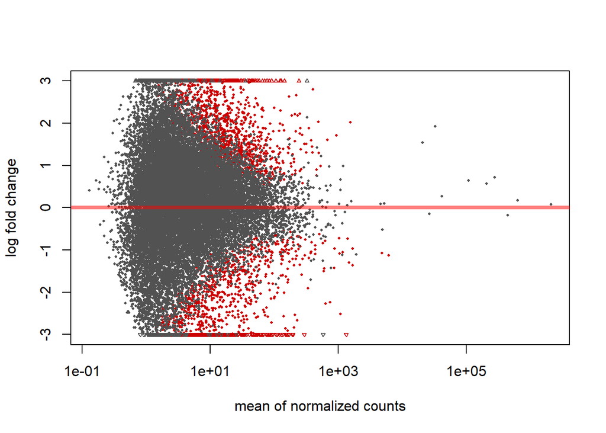

```r
plotMA(res_DC,ylim=c(-3,3))
```

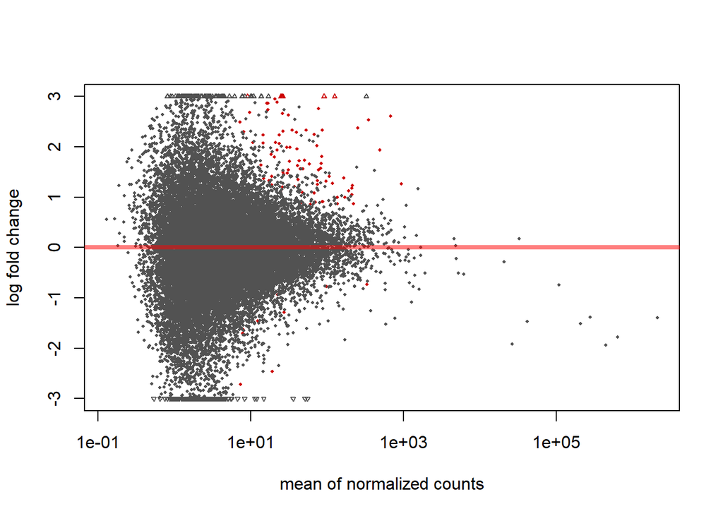

```r
plotMA(res_HC,ylim=c(-3,3))
```

## PCA plot

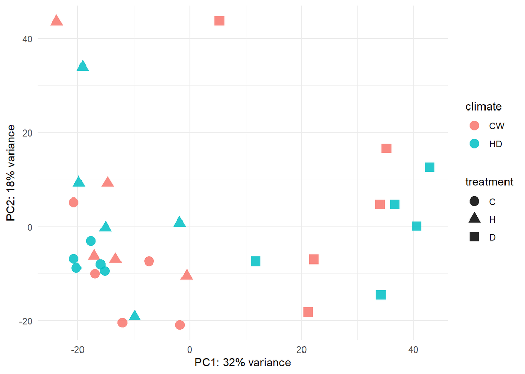

```r
vsd <- vst(dds, blind=FALSE)

data <- plotPCA(vsd,intgroup=c("climate","treatment","pop"), #ntop=10000
                returnData=TRUE)


# Measure percent variance
percentVar <- round(100 * attr(data,"percentVar"))

data$treatment <- factor(data$treatment, levels=c("C","H","D"), labels = c("C","H","D"))

ggplot(data, aes(PC1, PC2, color=climate, shape=treatment)) +
  geom_point(size=4, alpha=0.85) +
  xlab(paste0("PC1: ",percentVar[1],"% variance")) +
  ylab(paste0("PC2: ",percentVar[2],"% variance")) +
  theme_minimal()
```

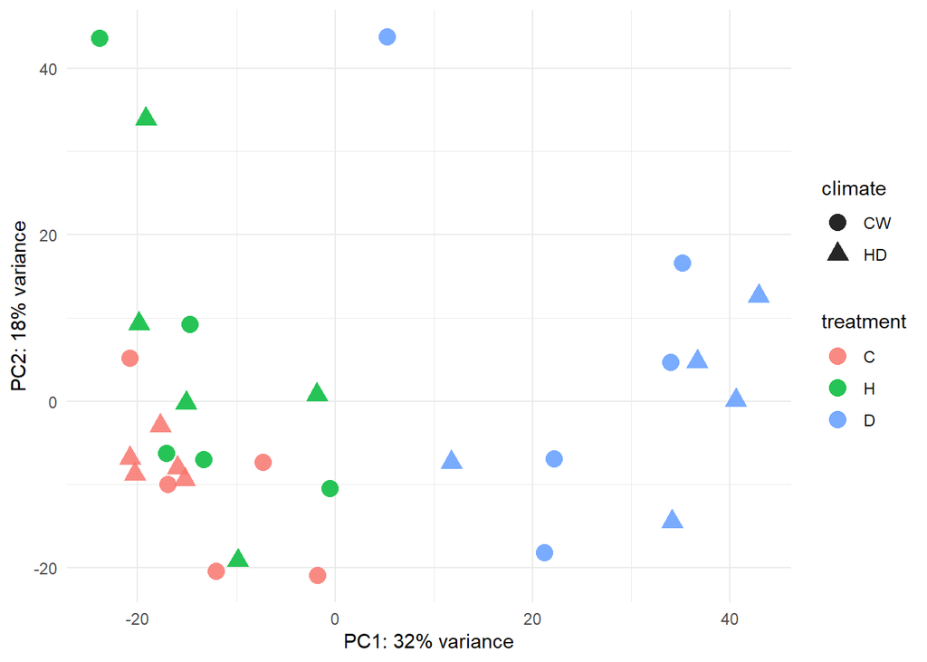

```r
ggplot(data, aes(PC1, PC2, color=treatment, shape=climate)) +
  geom_point(size=4, alpha=0.85) +
  xlab(paste0("PC1: ",percentVar[1],"% variance")) +
  ylab(paste0("PC2: ",percentVar[2],"% variance")) +
  theme_minimal()
```